# Analytical Modeling: MasterControl QAL Lead Progression (Mx vs Qx)

Group-5 {April Greenwood, Amiya Ranjan Sahoo,Caleb Call , Rob Sheehy}

April 13, 2026

```r
knitr::opts_chunk$set(
  echo = TRUE,
  warning = FALSE,
  message = FALSE
)
```

# 1 . Introduction

MasterControl provides enterprise software solutions to regulated life sciences organizations through two primary product lines: Qx, focused on quality and compliance management, and Mx, designed to support digital manufacturing operations. While Qx has demonstrated strong adoption and higher lead progression rates, the Mx product line has consistently underperformed relative to the company baseline.

Because manufacturing solutions require specific operational environments and decision-makers, broad targeting strategies may reduce conversion effectiveness. This project aims to investigate whether the current lead targeting approach for Mx is misaligned with the organizations and buyer personas that are most likely to adopt manufacturing-focused solutions.

By analyzing Qualified Account Lead (QAL) data across industries, manufacturing models, site functions, company tiers, geographic territories, and job titles, this study seeks to identify the structural factors that influence lead progression and to determine how the optimal customer profile for Mx differs from that of Qx.

# 2 . Dataset and Target Variable

The dataset used in this analysis contains 16,644 Qualified Account Lead (QAL) records spanning the period 2024–2025. Each record represents a lead interaction associated with a specific account and product solution.

The dataset contains account-level, contact-level, and campaign-related attributes that describe the context of each lead interaction.

Key variables include:

## 2.1 . Product Information

[output not shown]

## 2.2 . Account Characteristics

```
•   acct_target_industry
•   acct_manufacturing_model
•   acct_primary_site_function
•   acct_tier_rollup
•   acct_territory_rollup
```

## 2.3 . Contact Information

```
•   contact_lead_title
•   contact_lead_id
```

## 2.4 . Campaign and Lead Context

```
•   last_tactic_campaign_channel
•   priority
```

A binary target variable, progressed, is constructed from the sales stage field.

Lead progression is defined as advancement to SQL, SQO, or Won, representing movement to advanced stages of the sales funnel.

• progressed = 1 → SQL / SQO / Won

• progressed = 0 → all other outcomes

This formulation enables the problem to be framed as a binary classification task for predictive modeling.

# 3 . Analytical Objective

The primary objective of this project is to identify the account characteristics and buyer personas that most strongly influence lead progression for the Mx product line.

Specifically, the analysis seeks to:

```
•   Determine which industries and manufacturing models are most suitable for Mx
•   Identify which site functions indicate active manufacturing environments
•   Evaluate how company size and geographic territory influence progression
•   Determine which job titles and functional roles represent true Mx decision-makers
•   Compare these findings with the progression patterns observed for Qx
```

Understanding these relationships will help establish a data-driven Ideal Customer Profile (ICP) for Mx and clarify how Mx targeting should differ from Qx targeting.

# 4 . Modeling Approach

This project integrates descriptive, predictive, and prescriptive analytics to translate observed lead progression patterns into actionable insights.

Descriptive Analytics

The descriptive phase examines progression behavior across key business dimensions such as industry, manufacturing model, site function, company tier, geographic region, and job title. This stage identifies high-performing and underperforming segments within the dataset.

Predictive Analytics

Predictive modeling is used to estimate the probability that a qualified lead will progress beyond the initial qualification stage. By modeling lead progression outcomes, the analysis identifies the variables and feature combinations that most strongly influence success.

Prescriptive Analytics

The final phase translates descriptive and predictive findings into actionable recommendations for sales targeting and lead prioritization. This stage focuses on defining the most promising account and persona combinations for the Mx product line.

# 5 . Predictive Modeling Framework

After completing data preparation and feature engineering, several supervised machine learning models will be evaluated to estimate the probability that a qualified lead progresses beyond the initial qualification stage. The objective of this modeling phase is to identify the account characteristics and buyer attributes that most strongly influence lead progression, while also comparing the predictive performance of multiple algorithms.

The modeling framework includes the following models:

## 5.1 Model 1: Logistic Regression

A baseline interpretable model that estimates the relationship between predictor variables and the probability of lead progression. Logistic regression provides clear coefficient interpretations, allowing identification of features that increase or decrease progression likelihood.

## 5.2 Model 2: Elastic-Net Logistic Regression (glmnet)

A regularized extension of logistic regression that combines L1 (Lasso) and L2 (Ridge) penalties. Elastic-Net is particularly useful when working with a large number of engineered predictors, as it performs automatic feature selection and stabilizes model estimates in the presence of correlated variables.

## 5.3 Model 3: Decision Tree (CART)

A rule-based model that partitions the data into hierarchical segments based on predictor variables. Decision trees are useful for identifying interaction effects and uncovering interpretable decision rules that describe high-conversion account and title segments.

## 5.4 Model 4: Random Forest

An ensemble learning method that constructs multiple decision trees and aggregates their predictions. Random forests reduce overfitting and capture nonlinear relationships between predictors, while also providing measures of variable importance.

## 5.5 Model 5: Gradient Boosting / XGBoost

A boosted ensemble model that sequentially builds trees to improve predictive performance. Gradient boosting models are particularly effective for structured tabular datasets and often achieve strong predictive accuracy.

To evaluate model performance, the dataset will be divided into training and testing subsets using a stratified train–test split, ensuring that lead progression outcomes are proportionally represented across both samples.

During training, cross-validation will be used to reduce overfitting and improve model generalization. This approach allows model performance to be evaluated across multiple data partitions and helps ensure stability in predictive results.

Model performance will be assessed using standard classification metrics, including:

```
•   Accuracy
•   Precision
•   Recall
•   F1 Score
•   ROC–AUC
```

These metrics provide complementary perspectives on model performance and allow comparison across algorithms. The goal is to identify a model that balances predictive accuracy with interpretability while providing insights that can support improved lead targeting and segmentation strategies for the Mx product line.

# 6 . Client Deliverables

The final analysis is designed to produce clear, actionable recommendations addressing the client’s key business questions:

```
1.  Which account types should MasterControl target for Mx?(This includes identifying the most promising industries, manufacturing models, and site functions.)
2.  Which job titles convert best for Mx within those account types?(This includes identifying the seniority levels and functional roles associated with higher progression rates.)
3.  How does the optimal Mx profile differ from the Qx profile?(This comparison helps clarify where product targeting strategies should diverge.)
4.  Which accounts and personas represent cross-sell opportunities?(Identifying profiles that demonstrate strong progression potential for both product families.)
5.  What is the expected impact of improved targeting?(Estimating how refined account and persona targeting could improve Mx progression performance relative to the current baseline.)
```

# 7 . Business Value of the Analysis

Beyond addressing the specific client deliverables, this analysis provides broader strategic value for MasterControl.

The results can support:

```
•   improved sales targeting efficiency
•   better lead prioritization
•   clearer definition of the Ideal Customer Profile (ICP) for Mx
•   improved alignment between marketing, sales, and product strategy
•   identification of cross-sell opportunities across product lines
```

By establishing a data-driven understanding of which organizations and decision-makers are most likely to adopt Mx, MasterControl can allocate sales resources more effectively and improve overall progression performance for this strategically important product line.

# 8 . Libraries Loading, Data Preparation and Dataset Inspection

Before beginning the modeling process, the required libraries are loaded to support data manipulation, feature engineering, visualization, model development, and evaluation.

The workflow builds on the tidyverse ecosystem used during the exploratory data analysis phase, while incorporating additional libraries commonly used for predictive modeling and machine learning. These packages support tasks such as feature engineering, categorical encoding, model training, and performance evaluation.

Loading these libraries at the start ensures that the analytical environment is fully prepared for the modeling workflow and promotes reproducibility throughout the analysis.

## 8.1 . Loading Required Libraries

```r
# --------------------------------------------------
# Data Import & Manipulation
# --------------------------------------------------
library(readr)        # Reading CSV files
library(dplyr)        # Data manipulation
library(tidyr)        # Data reshaping
library(tibble)       # Modern data frames
library(stringr)      # String processing (useful for title feature engineering)
library(forcats)      # Factor handling
library(data.table)   # Fast file reading for large datasets

# --------------------------------------------------
# Data Cleaning & Exploration
# --------------------------------------------------
library(janitor)      # Clean column names
library(skimr)        # Detailed summary statistics
library(lubridate)    # Date handling

# --------------------------------------------------
# Missing Data Analysis
# --------------------------------------------------
library(naniar)       # Missing data visualization

# --------------------------------------------------
# Visualization
# --------------------------------------------------
library(ggplot2)      # Core visualization package
library(scales)       # Percent formatting
library(ggthemes)     # Professional plot themes
library(gridExtra)    # Arrange multiple plots
library(GGally)       # Pair plots and correlation visuals

# --------------------------------------------------
# Table Presentation
# --------------------------------------------------
library(gt)           # Professional formatted tables

# --------------------------------------------------
# Categorical Association
# --------------------------------------------------
library(rcompanion)   # Cramer's V for categorical correlation

# --------------------------------------------------
# Machine Learning & Modeling
# --------------------------------------------------
library(caret)        # Modeling framework and resampling
library(recipes)      # Feature engineering pipelines
library(glmnet)       # Elastic-Net regularized regression
library(rpart)        # Decision tree (CART)
library(rpart.plot)   # Decision tree visualization
library(randomForest) # Random Forest model
library(xgboost)      # Gradient boosting model
library(pROC)         # ROC curves and AUC evaluation

# --------------------------------------------------
# Global Settings
# --------------------------------------------------
theme_set(theme_minimal())   # Set default visualization theme
set.seed(123)                # Ensure reproducibility
```

## 8.2 . Loading the Dataset

The Qualified Account Lead (QAL) dataset used in this analysis contains lead-level observations describing account attributes, contact information, campaign context, and sales stage outcomes.

Each record represents a qualified account lead (QAL) associated with a specific account, campaign interaction, and product solution. This dataset forms the foundation for the predictive modeling framework developed in the following sections.

```r
# Load the MasterControl QAL dataset
qal_data <- read_csv("Mastercontrol QAL Performance.csv")

qal_data <- qal_data %>% clean_names()
```

## 8.3 . Initial Dataset Inspection

Before proceeding with modeling preparation, the dataset is inspected to verify that it has been imported correctly and to understand its overall structure. This step provides a quick overview of the dataset’s size, variable names, data types, and general characteristics.

These checks help confirm that the dataset is ready for further preparation and modeling.

```r
# ---------------------------
# Dataset Dimensions
# ---------------------------

dim_table <- tibble(
  Metric = c("Number of Rows", "Number of Columns"),
  Value  = c(nrow(qal_data), ncol(qal_data))
)
print(
dim_table %>%
  gt()
)
```

[output not shown]

[output cut: 410 more lines]

[output not shown]

```r
# ---------------------------
# Column Names
# ---------------------------

column_table <- tibble(
  Column_Name = colnames(qal_data)
)
print(
column_table %>%
  gt()
)
```

[output not shown]

[output cut: 419 more lines]

[output not shown]

```r
# ---------------------------
# Dataset Preview
# ---------------------------

preview_head <- head(qal_data, 10)
preview_tail <- tail(qal_data, 10)

preview_head %>% gt()
```

| acct_primary_site_function | acct_manufacturing_model | acct_target_industry | contact_lead_title | qal_id | contact_lead_id | next_stage_c | priority | acct_territory_rollup | acct_tier_rollup | solution | solution_rollup | last_tactic_campaign_channel | qal_cohort_date |
| --- | --- | --- | --- | --- | --- | --- | --- | --- | --- | --- | --- | --- | --- |
| Food and beverage | Consumer Packaged Goods | Non-Life Science | QA Manager | a0dPQ000005WbfuYAC | 0030c00002XPeNGAA1 | SQL | P1 - Webinar Demo | Americas | Medium | Mx | Mx | Online Ads | 2025-06-16 |
| Surgical instruments | In-House | Medical Device | Quality Manager | a0dPQ00000CRpkLYAT | 0030c00002ZaC9pAAF | Won | Priority 2 | Americas | Medium | Mx | Mx | SEO | 2025-11-13 |
| Cell therapies (CAR-T, NK) | Hospital Investigational Drug Unit | Blood & Biologics | ING | a0dPQ000000KWdFYAW | 0030c00002ZzekAAAR | Recycled | Priority 2 | EMEA | Large | Qx | Qx | Email | 2024-02-15 |
| In-vitro diagnostic (IVD) kits | In-House | Medical Device | Sr. Director of IT | a0dPQ000004LOWTYA4 | 0030c00002a0E0cAAE | Recycled | P1 - Webinar Demo | Americas | Medium | Logbooks | Mx | External Demand Gen | 2025-04-29 |
| Nutraceutical manufacturing | CMO | Pharma & BioTech | Sr. Manager, Quality Systems | a0dPQ000000BrKLYA0 | 0030c00002a1U5AAAU | Recycled | Priority 2 | Americas | Medium | Qx | Qx | Email | 2024-01-25 |
| Diagnostic Equipment | In-House | Medical Device | Document Control Specialist | a0dPQ000000g4aHYAQ | 0030c00002bKZ7iAAG | Recycled | Priority 2 | Americas | Medium | Qx | Qx | Email | 2024-04-11 |
| Animal Health | In-House | Pharma & BioTech | President | a0dPQ000001klhhYAA | 0030c00002ba6TDAAY | SQL | Priority 1 | Americas | Small | Qx | Qx | Online Ads | 2024-09-23 |
| Non-manufacturing organization | Software / Technology Development | Medical Device | PRRC | a0dPQ000001kbf7YAA | 0030c00002bkd4UAAQ | Recycled | Priority 2 | EMEA | Medium | Qx | Qx | Email | 2024-09-23 |
| In-vitro diagnostic (IVD) kits | In-House | Medical Device | Manager, Quality Assurance & Regulatory Affair | a0dPQ000000NRcDYAW | 0030c00002bmdO9AAI | Recycled | Priority 2 | EMEA | Medium | Qx | Qx | Email | 2024-02-22 |
| In-vitro diagnostic (IVD) kits | In-House | Medical Device | Manager, Quality Assurance & Regulatory Affair | a0dPQ000001FIorYAG | 0030c00002bmdO9AAI | Recycled | Priority 1 | EMEA | Medium | Qx | Qx | SEO | 2024-07-17 |

```r
preview_tail %>% gt()
```

| acct_primary_site_function | acct_manufacturing_model | acct_target_industry | contact_lead_title | qal_id | contact_lead_id | next_stage_c | priority | acct_territory_rollup | acct_tier_rollup | solution | solution_rollup | last_tactic_campaign_channel | qal_cohort_date |
| --- | --- | --- | --- | --- | --- | --- | --- | --- | --- | --- | --- | --- | --- |
| Animal Health | In-House | Pharma & BioTech | Information Manager | a0dPQ000004TovBYAS | 003a000002RPIsOAAX | Recycled | No Priority | EMEA | Medium | MISSING/BLANK | Qx | Outbound Prospecting | 2025-05-13 |
| Surgical instruments | CDMO | Medical Device | Vice President, Quality & Operations | a0dPQ000004SextYAC | 003a000002RQJ6lAAH | Recycled | No Priority | Americas | Small | MISSING/BLANK | Qx | MISSING/BLANK | 2025-05-11 |
| NA | NA | NA | Manager, Quality Systems | a0dPQ000001aUwfYAE | 003a000002RR63KAAT | Recycled | Priority 1 | NA | NA | Mx | Mx | Email | 2024-08-30 |
| Ophthalmic sterile drops | CMO | Pharma & BioTech | Director Of Operations | a0dPQ000001LB4kYAG | 003a000002TVkuoAAD | Recycled | Priority 2 | Americas | Medium | Logbooks | Mx | External Demand Gen | 2024-07-31 |
| Implantable devices | Outsources Manufacturing | Medical Device | Quality Assurance and Regulatory Engineer | a0dPQ000005wCihYAE | 003a000002TWf5UAAT | Recycled | P1 - Video Demo | Americas | Small | Qx | Qx | Online Ads | 2025-06-26 |
| Single-use disposables | In-House | Medical Device | Manager | a0dPQ000003gdrFYAQ | 003a000002TWfOlAAL | Recycled | Priority 2 | Americas | Medium | Mx | Mx | External Demand Gen | 2025-02-25 |
| Non-manufacturing organization | CRO | Pharma & BioTech | QA Manager | a0dPQ000000Hj3xYAC | 003a000002TXVfiAAH | Recycled | Priority 2 | Americas | Medium | Qx | Qx | Email | 2024-02-08 |
| Non-manufacturing organization | Services / Consulting | Medical Device | Director | a0dPQ000000P7pVYAS | 003a000002UEDRQAA5 | Recycled | Priority 2 | APAC & Oceania | Small | Qx | Qx | Email | 2024-02-26 |
| Secondary packaging | CPO | Non-Life Science | Director - QA/QC | a0dPQ000000NaijYAC | 003a000002UEGM0AAP | Recycled | Priority 2 | Americas | Medium | Qx | Qx | Email | 2024-02-22 |
| Secondary packaging | CPO | Non-Life Science | Director - QA/QC | a0dPQ000003XGlpYAG | 003a000002UEGM0AAP | Recycled | Priority 2 | Americas | Medium | Mx | Mx | External Demand Gen | 2025-02-18 |

```r
# ---------------------------
# Data Structure
# ---------------------------

structure_table <- tibble(
  Column = names(qal_data),
  Data_Type = sapply(qal_data, class),
  Unique_Values = sapply(qal_data, function(x) length(unique(x)))
)
print(
structure_table %>%
  gt()
)
```

[output not shown]

[output cut: 449 more lines]

[output not shown]

## 8.4 . Summary Statistics and Data Quality Checks

Before moving to feature engineering and modeling, it is important to evaluate the overall quality of the dataset. This includes examining summary statistics, identifying missing values, and evaluating the number of unique values in each variable.

These checks help identify potential data preparation tasks required before modeling.

```r
# ---------------------------
# Numeric Summary Statistics
# ---------------------------

numeric_data <- qal_data %>%
  select(where(is.numeric))

if(ncol(numeric_data) > 0){

summary_table <- summary(numeric_data) %>%
  as.data.frame() %>%
  rownames_to_column("Statistic")

summary_table %>%
  gt()

} else {

message("No numeric variables found in the dataset.")

}

# ---------------------------
# Detailed Dataset Overview
# ---------------------------

skim(qal_data)
```

Data summary

| Name | qal_data |
| --- | --- |
| Number of rows | 16644 |
| Number of columns | 14 |
| _______________________ |  |
| Column type frequency: |  |
| character | 13 |
| Date | 1 |
| ________________________ |  |
| Group variables | None |

**Variable type: character**

| skim_variable | n_missing | complete_rate | min | max | empty | n_unique | whitespace |
| --- | --- | --- | --- | --- | --- | --- | --- |
| acct_primary_site_function | 60 | 1.00 | 6 | 42 | 0 | 79 | 0 |
| acct_manufacturing_model | 101 | 0.99 | 3 | 34 | 0 | 19 | 0 |
| acct_target_industry | 45 | 1.00 | 7 | 17 | 0 | 5 | 0 |
| contact_lead_title | 4861 | 0.71 | 2 | 125 | 0 | 6588 | 0 |
| qal_id | 0 | 1.00 | 18 | 18 | 0 | 16644 | 0 |
| contact_lead_id | 3 | 1.00 | 18 | 18 | 0 | 15371 | 0 |
| next_stage_c | 394 | 0.98 | 3 | 8 | 0 | 8 | 0 |
| priority | 0 | 1.00 | 5 | 20 | 0 | 11 | 0 |
| acct_territory_rollup | 132 | 0.99 | 4 | 14 | 0 | 6 | 0 |
| acct_tier_rollup | 45 | 1.00 | 5 | 6 | 0 | 4 | 0 |
| solution | 0 | 1.00 | 2 | 19 | 0 | 12 | 0 |
| solution_rollup | 0 | 1.00 | 2 | 2 | 0 | 2 | 0 |
| last_tactic_campaign_channel | 0 | 1.00 | 3 | 20 | 0 | 12 | 0 |

**Variable type: Date**

| skim_variable | n_missing | complete_rate | min | max | median | n_unique |
| --- | --- | --- | --- | --- | --- | --- |
| qal_cohort_date | 0 | 1 | 2024-01-01 | 2025-12-31 | 2024-11-27 | 595 |

```r
# ---------------------------
# Missing Values Analysis
# ---------------------------

missing_table <- tibble(
  Variable = names(qal_data),
  Missing_Count = colSums(is.na(qal_data)),
  Missing_Percent = round(colSums(is.na(qal_data)) / nrow(qal_data) * 100, 2)
)
print(
missing_table %>%
  arrange(desc(Missing_Percent)) %>%
  gt()
)
```

[output not shown]

[output cut: 449 more lines]

[output not shown]

```r
# ---------------------------
# Variable Cardinality
# ---------------------------

cardinality_table <- tibble(
  Variable = names(qal_data),
  Unique_Values = sapply(qal_data, function(x) length(unique(x)))
)
print(
cardinality_table %>%
  arrange(desc(Unique_Values)) %>%
  gt()
)
```

[output not shown]

[output cut: 434 more lines]

[output not shown]

## 8.5 . Data Integrity Checks

Before proceeding to modeling preparation, several additional integrity checks are performed to confirm that the dataset structure is reliable. These checks ensure that column names are standardized, date fields are correctly parsed, and that no unintended duplicate records exist.

The following checks are conducted:

```
•   verification of column naming format
•   validation of date variable type
•   detection of duplicated rows
•   confirmation that the primary identifier (qal_id) is unique
```

These checks help prevent data quality issues that could affect downstream modeling results.

```r
# --------------------------------------------------
# 1. Column Names
# --------------------------------------------------

column_format_table <- tibble(
  Column_Name = names(qal_data)
)
print(
column_format_table %>%
  gt()
)
```

[output not shown]

[output cut: 419 more lines]

[output not shown]

```r
# --------------------------------------------------
# 2. Date Variable Type
# --------------------------------------------------

date_type_table <- tibble(
  Variable = "qal_cohort_date",
  Data_Type = class(qal_data$qal_cohort_date)
)
print(
date_type_table %>%
  gt()
)
```

[output not shown]

[output cut: 408 more lines]

[output not shown]

```r
# --------------------------------------------------
# 3. Duplicate Row Check
# --------------------------------------------------

duplicate_rows <- sum(duplicated(qal_data))

duplicate_table <- tibble(
  Metric = "Duplicate Rows (Full Record)",
  Count = duplicate_rows
)
print(
duplicate_table %>%
  gt()
)
```

[output not shown]

[output cut: 408 more lines]

[output not shown]

```r
# --------------------------------------------------
# 4. qal_id Uniqueness Check
# --------------------------------------------------

id_check_table <- tibble(
  Metric = c("Total Records", "Unique qal_id", "Duplicate qal_id"),
  Value = c(
    nrow(qal_data),
    n_distinct(qal_data$qal_id),
    nrow(qal_data) - n_distinct(qal_data$qal_id)
  )
)

id_check_table %>%
  gt()
```

| Metric | Value |
| --- | --- |
| Total Records | 16644 |
| Unique qal_id | 16644 |
| Duplicate qal_id | 0 |

```r
# --------------------------------------------------
# 5. Inspect Duplicate Records (if any)
# --------------------------------------------------

duplicate_records <- qal_data %>%
  filter(duplicated(.))

duplicate_records %>%
  head(10) %>%
  gt()
```

| acct_primary_site_function | acct_manufacturing_model | acct_target_industry | contact_lead_title | qal_id | contact_lead_id | next_stage_c | priority | acct_territory_rollup | acct_tier_rollup | solution | solution_rollup | last_tactic_campaign_channel | qal_cohort_date |
| --- | --- | --- | --- | --- | --- | --- | --- | --- | --- | --- | --- | --- | --- |

## 8.6 . Categorical Distribution Overview

Before modeling preparation, it is useful to examine the distribution of major categorical variables to understand class imbalance and rare categories.

```r
categorical_vars <- qal_data %>%
  select(where(is.character))

for(col in names(categorical_vars)) {

  freq_table <- qal_data %>%
    count(.data[[col]], sort = TRUE)

  print(
    gt(freq_table) %>%
      tab_header(
        title = paste("Distribution of", col)
      )
  )
}
```

[output not shown]

## 8.7 . Detection of Non-Standard Missing Labels

The dataset was checked for multiple forms of missing information, including standard NA values, non-standard text labels such as:

```
•   "Unknown"
•   "Not Enough Info Found"
•   "MISSING/BLANK"
•  Empty cells (””)
```

```r
missing_patterns <- bind_rows(

  qal_data %>%
    summarise(across(everything(),
                     ~ sum(is.na(.)))) %>%
    mutate(Missing_Type = "NA"),

  qal_data %>%
    summarise(across(everything(),
                     ~ sum(. == "Unknown", na.rm = TRUE))) %>%
    mutate(Missing_Type = "Unknown"),

  qal_data %>%
    summarise(across(everything(),
                     ~ sum(. == "Not Enough Info Found", na.rm = TRUE))) %>%
    mutate(Missing_Type = "Not Enough Info Found"),

  qal_data %>%
    summarise(across(everything(),
                     ~ sum(. == "MISSING/BLANK", na.rm = TRUE))) %>%
    mutate(Missing_Type = "MISSING/BLANK"),

  qal_data %>%
    summarise(across(everything(),
                     ~ sum(. == "", na.rm = TRUE))) %>%
    mutate(Missing_Type = 'Empty Cells ("")')

) %>%
  relocate(Missing_Type)
```

[output not shown]

```r
missing_patterns %>%
  gt()
```

[output not shown]

# 9 . Data Preparation for Modeling

After completing the initial data audit, the next step is to prepare the dataset for predictive modeling. This phase focuses on cleaning the data, standardizing missing values, defining the target variable, removing records with undefined outcomes, and creating a structured base dataset that can later be used for feature engineering and model development.

At this stage, the objective is not yet to create engineered features, but rather to ensure that the underlying data is clean, consistent, and suitable for downstream modeling tasks.

The main preparation steps include:

```
•   standardizing non-standard missing values
•   confirming the effect of missing-value conversion
•   removing records with undefined target outcomes
•   constructing the binary target variable
•   creating the modeling base dataset
•   reviewing the final class distribution
```

## 9.1 . Create a Working Copy of the Dataset

Before applying any transformations, a working copy of the cleaned dataset is created. This preserves the original imported dataset and allows all modeling-related preparation steps to be performed in a controlled and reproducible way.

```r
# Creating a working copy for modeling preparation
qal_model_base <- qal_data
```

## 9.2 . Standardize Non-Standard Missing Labels

The dataset contains several forms of missing information beyond standard NA values. These include text-based placeholders such as “Unknown”, “Not Enough Info Found”, and “MISSING/BLANK”. To ensure consistency during modeling, these values are converted into standard NA values.

This step improves data quality and prevents placeholder labels from being treated as legitimate predictor categories later in the analysis.

```r
# Converting non-standard missing labels to NA
qal_model_base <- qal_model_base %>%
  mutate(across(
    everything(),
    ~ case_when(
      . %in% c("Unknown",
               "Not Enough Info Found",
               "MISSING/BLANK") ~ NA_character_,
      TRUE ~ as.character(.)
    )
  ))

# Convert qal_cohort_date back to Date format
qal_model_base <- qal_model_base %>%
  mutate(qal_cohort_date = lubridate::mdy(qal_cohort_date))
```

## 9.3 . Review Missing Values After Standardization

```r
missing_after_cleaning <- tibble(
  Variable = names(qal_model_base),
  Missing_Count = colSums(is.na(qal_model_base)),
  Missing_Percent = round(colSums(is.na(qal_model_base)) / nrow(qal_model_base) * 100, 2)
)

missing_after_cleaning %>%
  arrange(desc(Missing_Percent)) %>%
  gt()
```

| Variable | Missing_Count | Missing_Percent |
| --- | --- | --- |
| qal_cohort_date | 16644 | 100.00 |
| contact_lead_title | 4861 | 29.21 |
| acct_primary_site_function | 2610 | 15.68 |
| acct_manufacturing_model | 2526 | 15.18 |
| solution | 963 | 5.79 |
| next_stage_c | 394 | 2.37 |
| acct_target_industry | 226 | 1.36 |
| last_tactic_campaign_channel | 149 | 0.90 |
| acct_territory_rollup | 138 | 0.83 |
| acct_tier_rollup | 45 | 0.27 |
| contact_lead_id | 3 | 0.02 |
| qal_id | 0 | 0.00 |
| priority | 0 | 0.00 |
| solution_rollup | 0 | 0.00 |

## 9.4 . Remove Records With Undefined Outcome

The outcome variable for modeling is derived from next_stage_c. Records with missing values in this column do not have a defined sales progression outcome and therefore cannot be used in supervised learning.

These records are removed before creating the target variable.

```r
# Count rows with undefined target outcome
undefined_outcome_table <- tibble(
  Metric = c("Total Records Before Filtering",
             "Records With Missing next_stage_c",
             "Records Remaining After Filtering"),
  Value = c(
    nrow(qal_model_base),
    sum(is.na(qal_model_base$next_stage_c)),
    sum(!is.na(qal_model_base$next_stage_c))
  )
)

undefined_outcome_table %>%
  gt()
```

| Metric | Value |
| --- | --- |
| Total Records Before Filtering | 16644 |
| Records With Missing next_stage_c | 394 |
| Records Remaining After Filtering | 16250 |

```r
# Remove records with missing next_stage_c
qal_model_base <- qal_model_base %>%
  filter(!is.na(next_stage_c))
```

## 9.5 . Construct the Target Variable

The modeling objective is to predict whether a lead progressed to a deeper sales stage. A binary target variable named progressed is created from next_stage_c.

Leads that reached SQL, SQO, or Won are classified as progressed (1), while all other observed outcomes are treated as non-progressed (0).

```r
# Create binary target variable
qal_model_base <- qal_model_base %>%
  mutate(
    progressed = if_else(
      next_stage_c %in% c("SQL", "SQO", "Won"),
      1,
      0
    )
  )

# Review target mapping
target_mapping_table <- qal_model_base %>%
  count(next_stage_c, progressed, sort = TRUE)

target_mapping_table %>%
  gt()
```

| next_stage_c | progressed | n |
| --- | --- | --- |
| Recycled | 0 | 12019 |
| SQL | 1 | 2694 |
| Exclude | 0 | 1219 |
| SQO | 1 | 254 |
| Won | 1 | 40 |
| Lost | 0 | 12 |
| MQL | 0 | 10 |
| INQ | 0 | 2 |

## 9.6 . Review Target Variable Distribution

After the target variable is created, the class distribution should be reviewed to understand the balance between progressed and non-progressed leads. This is important because class imbalance can affect model performance and interpretation.

```r
target_distribution <- qal_model_base %>%
  count(progressed) %>%
  mutate(
    Percentage = round(n / sum(n) * 100, 2)
  )

target_distribution %>%
  gt()
```

| progressed | n | Percentage |
| --- | --- | --- |
| 0 | 13262 | 81.61 |
| 1 | 2988 | 18.39 |

## 9.7 . Prepare the Modeling Base Dataset

At this stage, the dataset is cleaned and the target variable has been defined. The next step is to prepare the base dataset that will be used in later stages such as feature engineering and train-test splitting.

For now, identifier columns and raw outcome columns are retained for traceability, but they are clearly flagged as variables that will not be used as predictors during model training.

```r
model_base_summary <- tibble(
  Metric = c("Total Records in Modeling Base Dataset",
             "Total Columns in Modeling Base Dataset"),
  Value = c(nrow(qal_model_base), ncol(qal_model_base))
)

model_base_summary %>%
  gt()
```

| Metric | Value |
| --- | --- |
| Total Records in Modeling Base Dataset | 16250 |
| Total Columns in Modeling Base Dataset | 15 |

```r
# Preview key columns
qal_model_base %>%
  select(qal_id, contact_lead_id, next_stage_c, progressed, solution_rollup, qal_cohort_date) %>%
  head(10) %>%
  gt()
```

| qal_id | contact_lead_id | next_stage_c | progressed | solution_rollup | qal_cohort_date |
| --- | --- | --- | --- | --- | --- |
| a0dPQ000005WbfuYAC | 0030c00002XPeNGAA1 | SQL | 1 | Mx | NA |
| a0dPQ00000CRpkLYAT | 0030c00002ZaC9pAAF | Won | 1 | Mx | NA |
| a0dPQ000000KWdFYAW | 0030c00002ZzekAAAR | Recycled | 0 | Qx | NA |
| a0dPQ000004LOWTYA4 | 0030c00002a0E0cAAE | Recycled | 0 | Mx | NA |
| a0dPQ000000BrKLYA0 | 0030c00002a1U5AAAU | Recycled | 0 | Qx | NA |
| a0dPQ000000g4aHYAQ | 0030c00002bKZ7iAAG | Recycled | 0 | Qx | NA |
| a0dPQ000001klhhYAA | 0030c00002ba6TDAAY | SQL | 1 | Qx | NA |
| a0dPQ000001kbf7YAA | 0030c00002bkd4UAAQ | Recycled | 0 | Qx | NA |
| a0dPQ000000NRcDYAW | 0030c00002bmdO9AAI | Recycled | 0 | Qx | NA |
| a0dPQ000001FIorYAG | 0030c00002bmdO9AAI | Recycled | 0 | Qx | NA |

## 9.8 . Identify Columns for Exclusion From Predictors

Some columns should not be used directly as predictors because they are identifiers or because they contain the raw outcome information used to create the target variable.

These columns will be excluded later during model matrix construction, but they are identified now to ensure a clear modeling workflow.

```r
predictor_exclusion_table <- tibble(
  Column = c("qal_id", "contact_lead_id", "next_stage_c"),
  Reason = c(
    "Unique record identifier",
    "Unique contact identifier",
    "Raw outcome field used to create the target variable"
  )
)

predictor_exclusion_table %>%
  gt()
```

| Column | Reason |
| --- | --- |
| qal_id | Unique record identifier |
| contact_lead_id | Unique contact identifier |
| next_stage_c | Raw outcome field used to create the target variable |

## 9.9 . Final Check Before Feature Engineering

Before moving to feature engineering, a final confirmation is made to ensure that the modeling base dataset is complete, the target variable is defined, and missing values have been standardized.

This serves as the final checkpoint before the dataset is transformed into model-ready features.

```r
final_preparation_check <- tibble(
  Metric = c(
    "Records Available for Modeling",
    "Progressed Class (1)",
    "Non-Progressed Class (0)",
    "Columns with Remaining Missing Values"
  ),
  Value = c(
    nrow(qal_model_base),
    sum(qal_model_base$progressed == 1),
    sum(qal_model_base$progressed == 0),
    sum(colSums(is.na(qal_model_base)) > 0)
  )
)

final_preparation_check %>%
  gt()
```

| Metric | Value |
| --- | --- |
| Records Available for Modeling | 16250 |
| Progressed Class (1) | 2988 |
| Non-Progressed Class (0) | 13262 |
| Columns with Remaining Missing Values | 10 |

## 9.10 . Additional Pre-Modeling Validation Checks

Before proceeding to feature engineering, several additional validation checks are performed to confirm that the modeling dataset is structurally sound. These checks verify the distribution of product types (Mx vs Qx), confirm that the progression target variable behaves as expected across products, ensure that the target variable contains no missing values, validate the date variable format, and review the overall dataset structure.

These checks provide an additional safeguard to ensure that the dataset is ready for feature engineering and subsequent model development.

```r
# --------------------------------------------------
# Additional Dataset Validation Checks
# --------------------------------------------------

# 1. Product Distribution (Mx vs Qx)
product_distribution <- qal_model_base %>%
  count(solution_rollup) %>%
  mutate(Percentage = round(n / sum(n) * 100, 2))

product_distribution %>%
  gt() %>%
  tab_header(
    title = "Distribution of Product Types (Mx vs Qx)"
  )
```

Distribution of Product Types (Mx vs Qx)

| solution_rollup | n | Percentage |
| --- | --- | --- |
| Mx | 4081 | 25.11 |
| Qx | 12169 | 74.89 |

```r
# 2. Progression Distribution by Product
progression_by_product <- qal_model_base %>%
  count(solution_rollup, progressed) %>%
  group_by(solution_rollup) %>%
  mutate(Percentage = round(n / sum(n) * 100, 2))

progression_by_product %>%
  gt() %>%
  tab_header(
    title = "Progression Distribution by Product"
  )
```

Progression Distribution by Product

| progressed | n | Percentage |
| --- | --- | --- |
| Mx |  |  |
| 0 | 3552 | 87.04 |
| 1 | 529 | 12.96 |
| Qx |  |  |
| 0 | 9710 | 79.79 |
| 1 | 2459 | 20.21 |

```r
# 3. Verify No Missing Values in Target Variable
target_missing_check <- tibble(
  Metric = "Missing Values in Target Variable (progressed)",
  Value = sum(is.na(qal_model_base$progressed))
)

target_missing_check %>%
  gt()
```

| Metric | Value |
| --- | --- |
| Missing Values in Target Variable (progressed) | 0 |

```r
# 4. Confirm Date Variable Type
date_type_check <- tibble(
  Variable = "qal_cohort_date",
  Data_Type = class(qal_model_base$qal_cohort_date)
)

date_type_check %>%
  gt()
```

| Variable | Data_Type |
| --- | --- |
| qal_cohort_date | Date |

```r
# 5. Review Dataset Structure
structure_table <- tibble(
  Column = names(qal_model_base),
  Data_Type = sapply(qal_model_base, class),
  Unique_Values = sapply(qal_model_base, function(x) length(unique(x)))
)

structure_table %>%
  gt() %>%
  tab_header(
    title = "Modeling Dataset Structure Overview"
  )
```

Modeling Dataset Structure Overview

| Column | Data_Type | Unique_Values |
| --- | --- | --- |
| acct_primary_site_function | character | 79 |
| acct_manufacturing_model | character | 19 |
| acct_target_industry | character | 5 |
| contact_lead_title | character | 6460 |
| qal_id | character | 16250 |
| contact_lead_id | character | 15049 |
| next_stage_c | character | 8 |
| priority | character | 11 |
| acct_territory_rollup | character | 6 |
| acct_tier_rollup | character | 5 |
| solution | character | 12 |
| solution_rollup | character | 2 |
| last_tactic_campaign_channel | character | 12 |
| qal_cohort_date | Date | 1 |
| progressed | numeric | 2 |

# 10 . Feature Engineering

After preparing the modeling base dataset, the next step is to engineer features that improve the predictive power and interpretability of the models. Feature engineering is especially important in this project because several variables are high-cardinality categorical fields, free-text job titles, or date variables that require transformation before they can be used effectively in machine learning models.

The goal of this stage is to convert raw variables into structured, meaningful predictors that better represent account characteristics, buyer roles, and lead context. This step is expected to play a major role in identifying the profiles most likely to progress and in supporting the final business deliverables related to Mx targeting and cross-sell opportunities.

The main feature engineering tasks include:

```
•   extracting structured information from job titles
•   deriving time-based features from cohort dates
•   grouping rare categories in high-cardinality variables
•   preserving meaningful missingness where appropriate
•   creating analysis-ready categorical predictors for modeling
```

## 10.1 . Create a Working Copy for Feature Engineering

Before creating new predictors, a separate working copy of the modeling dataset is created. This preserves the prepared base dataset and allows feature engineering steps to be applied in a controlled and reproducible manner.

```r
# --------------------------------------------------
# Create Feature Engineering Working Dataset
# --------------------------------------------------

qal_features <- qal_model_base
```

## 10.2 . Extract Time-Based Features from qal_cohort_date

The cohort date can capture temporal patterns in lead performance. Leads from certain quarters or years may convert differently.

Create:

```
•   Year
•   Quarter
•   Month
```

```r
# --------------------------------------------------
# Time-Based Features
# --------------------------------------------------

qal_features <- qal_features %>%
  mutate(
    cohort_year = lubridate::year(qal_cohort_date),
    cohort_quarter = lubridate::quarter(qal_cohort_date),
    cohort_month = lubridate::month(qal_cohort_date)

  )
```

```r
qal_features <- qal_features %>%
  mutate(
    cohort_year_quarter = paste0(cohort_year, "-Q", cohort_quarter)
  )
```

## 10.3 . Preserve Missingness Indicators

Some missing values may carry information (for example missing titles). Create binary indicators for missing fields. This allows models to learn whether missing titles behave differently.

```r
# --------------------------------------------------
# Missing Value Indicators
# --------------------------------------------------

qal_features <- qal_features %>%
  mutate(
    title_missing = if_else(is.na(contact_lead_title), 1, 0)
  )
```

## 10.4 .Group Rare Categories in High-Cardinality Variables

Some categorical variables have very small categories that add noise.

We group rare categories into “Other”.

Variables most likely affected:

```
•   acct_primary_site_function
•   acct_manufacturing_model
•   last_tactic_campaign_channel

This keeps the top frequent categories and groups the rest.
```

```r
# --------------------------------------------------
# Group Rare Categories
# --------------------------------------------------

qal_features <- qal_features %>%
  mutate(

    acct_primary_site_function =
      forcats::fct_lump_n(acct_primary_site_function, n = 10),

    acct_manufacturing_model =
      forcats::fct_lump_n(acct_manufacturing_model, n = 10),

    last_tactic_campaign_channel =
      forcats::fct_lump_n(last_tactic_campaign_channel, n = 8)

  )
```

## 10.5 .Convert Core Predictors to Factor Type

Most variables in your dataset are categorical predictors. Converting them to factors ensures modeling frameworks treat them correctly.The target variable remains numeric (0/1).

```r
# --------------------------------------------------
# Convert Categorical Predictors to Factors
# --------------------------------------------------

qal_features <- qal_features %>%
  mutate(
    acct_primary_site_function = as.factor(acct_primary_site_function),
    acct_manufacturing_model = as.factor(acct_manufacturing_model),
    acct_target_industry = as.factor(acct_target_industry),
    acct_territory_rollup = as.factor(acct_territory_rollup),
    acct_tier_rollup = as.factor(acct_tier_rollup),
    solution = as.factor(solution),
    solution_rollup = as.factor(solution_rollup),
    last_tactic_campaign_channel = as.factor(last_tactic_campaign_channel),
    priority = as.factor(priority),
    cohort_year = as.factor(cohort_year),
    cohort_quarter = as.factor(cohort_quarter),
    cohort_month = as.factor(cohort_month),
    cohort_year_quarter = as.factor(cohort_year_quarter)
  )
```

## 10.6 .Review the Engineered Dataset

Check the structure and confirm new variables.

```r
# --------------------------------------------------
# Review Engineered Dataset
# --------------------------------------------------

feature_structure <- tibble(
  Column = names(qal_features),
  Data_Type = sapply(qal_features, class),
  Unique_Values = sapply(qal_features, function(x) length(unique(x)))
)

feature_structure %>%
  gt() %>%
  tab_header(
    title = "Engineered Dataset Structure"
  )
```

Engineered Dataset Structure

| Column | Data_Type | Unique_Values |
| --- | --- | --- |
| acct_primary_site_function | factor | 12 |
| acct_manufacturing_model | factor | 12 |
| acct_target_industry | factor | 5 |
| contact_lead_title | character | 6460 |
| qal_id | character | 16250 |
| contact_lead_id | character | 15049 |
| next_stage_c | character | 8 |
| priority | factor | 11 |
| acct_territory_rollup | factor | 6 |
| acct_tier_rollup | factor | 5 |
| solution | factor | 12 |
| solution_rollup | factor | 2 |
| last_tactic_campaign_channel | factor | 10 |
| qal_cohort_date | Date | 1 |
| progressed | numeric | 2 |
| cohort_year | factor | 1 |
| cohort_quarter | factor | 1 |
| cohort_month | factor | 1 |
| cohort_year_quarter | factor | 1 |
| title_missing | numeric | 2 |

## 10.7 . Final Check Before Title Feature Engineering

Confirm dataset integrity before handling titles.

```r
final_feature_check <- tibble(
  Metric = c(
    "Records",
    "Columns",
    "Progressed Leads",
    "Non-Progressed Leads"
  ),
  Value = c(
    nrow(qal_features),
    ncol(qal_features),
    sum(qal_features$progressed == 1),
    sum(qal_features$progressed == 0)
  )
)

final_feature_check %>%
  gt()
```

| Metric | Value |
| --- | --- |
| Records | 16250 |
| Columns | 20 |
| Progressed Leads | 2988 |
| Non-Progressed Leads | 13262 |

## 10.8 .Title Feature Engineering

### 10.8.1 .Clean the Title Text

Before extracting structured signals, the raw title text is standardized so that titles with different capitalization, spacing, or punctuation can be interpreted consistently. This step preserves the original title field while creating a cleaned version for feature engineering.

```r
# --------------------------------------------------
# Clean Contact Lead Title
# --------------------------------------------------

qal_features <- qal_features %>%
  mutate(
    title_clean = contact_lead_title,
    title_clean = str_to_lower(title_clean),
    title_clean = iconv(title_clean, from = "", to = "ASCII//TRANSLIT"),
    title_clean = str_replace_all(title_clean, "[^a-z0-9/&+ -]", " "),
    title_clean = str_replace_all(title_clean, "\\s+", " "),
    title_clean = str_trim(title_clean)
  )
```

### 10.8.2 .Create Seniority Features

The title field contains strong signals about decision-making authority. Seniority is extracted to identify whether the contact is an executive, vice president, director, manager, or an individual contributor.

To ensure that all titles are included, any title that does not match the main seniority rules is assigned to “Other”, while missing titles are explicitly preserved as “Missing”.

```r
# --------------------------------------------------
# Title Seniority
# --------------------------------------------------

qal_features <- qal_features %>%
  mutate(
    title_seniority = case_when(

      # Missing titles
      is.na(contact_lead_title) | title_clean == "" ~ "Missing",

      # Vice Presidents (checked first to avoid being captured as Executive)
      str_detect(title_clean,
                 "\\bvp\\b|vice president|svp|evp|senior vice president|executive vice president|assistant vice president|associate vice president") ~ "VP",

      # C-Suite Executives
      str_detect(title_clean,
                 "\\bchief\\b|\\bceo\\b|\\bcfo\\b|\\bcoo\\b|\\bcio\\b|\\bcto\\b|\\bpresident\\b|chief .* officer|founder|co founder|owner|partner|principal") ~ "Executive",

      # Directors
      str_detect(title_clean,
                 "\\bdirector\\b|associate director|senior director|executive director|global director|site director|\\bhead\\b") ~ "Director",

      # Managers
      str_detect(title_clean,
                 "\\bmanager\\b|general manager|senior manager|assistant manager|group manager|project manager|program manager|supervisor|team lead|\\blead\\b") ~ "Manager",

      # Individual contributors
      str_detect(title_clean,
                 "engineer|scientist|specialist|analyst|associate|coordinator|administrator|technician|consultant|representative|advisor|developer|programmer|chemist|pharmacist|assessor|inspector|officer") ~ "Individual_Contributor",

      # Everything else
      TRUE ~ "Other"
    ),

    title_seniority = as.factor(title_seniority)
  )
```

### 10.8.3 .Create Functional Role Features

In addition to seniority, titles also indicate the department or business function the contact belongs to. These roles are especially important for distinguishing Mx and Qx buyer profiles.

Each title is assigned to one primary functional category. Missing titles are preserved as “Missing”, and any title that does not match the major business patterns is assigned to “Other”.

```r
# --------------------------------------------------
# Title Functional Role
# --------------------------------------------------

qal_features <- qal_features %>%
  mutate(
    title_function = case_when(

      is.na(contact_lead_title) | title_clean == "" ~ "Missing",

      str_detect(title_clean,
                 "quality|\\bqa\\b|\\bqc\\b|qms|compliance|validation|document control|sterility assurance|quality systems|quality control|quality assurance") ~ "Quality_Compliance",

      str_detect(title_clean,
                 "regulatory|\\bra\\b|reg affairs|regulatory affairs|qualified person|dscsa") ~ "Regulatory",

      str_detect(title_clean,
                 "manufacturing|production|plant|process|operations|operational excellence|continuous improvement|lean manufacturing|industrial") ~ "Manufacturing_Operations",

      str_detect(title_clean,
                 "engineer|engineering|scientist|research|development|r d|r&d|product development|process development|automation|laboratory") ~ "Engineering_RD",

      str_detect(title_clean,
                 "information technology|\\bit\\b|systems|software|digital|technology|data|infrastructure|computer|programmer|developer|architect") ~ "IT_Systems",

      str_detect(title_clean,
                 "sales|business development|commercial|marketing|account manager|account executive|product manager|customer success|go to market") ~ "Commercial_Business",

      str_detect(title_clean,
                 "supply chain|procurement|logistics|warehouse|cold chain|purchasing|supplier|distribution") ~ "Supply_Chain",

      str_detect(title_clean,
                 "clinical|medical|post market|surveillance|patient|pharmacovigilance") ~ "Clinical_Medical",

      str_detect(title_clean,
                 "finance|financial|accountant|accounts payable|human resources|\\bhr\\b|administration|admin|management assistant|tax|payroll") ~ "Finance_Admin",

      TRUE ~ "Other"
    ),

    title_function = as.factor(title_function)
  )
```

### 10.8.4 .Create Keyword Flags

Binary keyword flags preserve important signals that may overlap across titles. This is especially useful when one title contains multiple important concepts such as both seniority and department.

```r
# --------------------------------------------------
# Title Keyword Flags
# --------------------------------------------------

qal_features <- qal_features %>%
  mutate(
    has_quality        = if_else(!is.na(title_clean) & str_detect(title_clean, "quality|\\bqa\\b|\\bqc\\b|qms|compliance|validation"), 1, 0),

    has_regulatory     = if_else(!is.na(title_clean) & str_detect(title_clean, "regulatory|\\bra\\b|reg affairs|qualified person"), 1, 0),

    has_manufacturing  = if_else(!is.na(title_clean) & str_detect(title_clean, "manufacturing|production|plant|process|industrial"), 1, 0),

    has_operations     = if_else(!is.na(title_clean) & str_detect(title_clean, "operations|operational excellence|continuous improvement"), 1, 0),

    has_engineering    = if_else(!is.na(title_clean) & str_detect(title_clean, "engineer|engineering|scientist|research|development|automation"), 1, 0),

    has_it             = if_else(!is.na(title_clean) & str_detect(title_clean, "information technology|\\bit\\b|systems|software|digital|data|technology"), 1, 0),

    has_sales          = if_else(!is.na(title_clean) & str_detect(title_clean, "sales|business development|commercial|marketing|account"), 1, 0),

    has_supply_chain   = if_else(!is.na(title_clean) & str_detect(title_clean, "supply chain|procurement|logistics|warehouse|supplier|purchasing"), 1, 0),

    has_executive      = if_else(!is.na(title_clean) & str_detect(title_clean, "\\bchief\\b|\\bceo\\b|\\bcfo\\b|\\bcoo\\b|\\bcio\\b|\\bcto\\b|founder|owner|partner"), 1, 0),

    has_vp             = if_else(!is.na(title_clean) & str_detect(title_clean, "\\bvp\\b|vice president"), 1, 0),

    has_director       = if_else(!is.na(title_clean) & str_detect(title_clean, "\\bdirector\\b|\\bhead\\b"), 1, 0),

    has_manager        = if_else(!is.na(title_clean) & str_detect(title_clean, "\\bmanager\\b|supervisor|team lead|general manager"), 1, 0)
  )
```

### 10.8.5 .Review the Title Features

After engineering the title-based predictors, the new variables should be reviewed to confirm that all titles have been assigned correctly and that no rows have been lost. This review also helps confirm that the “Missing” and “Other” fallback categories are working as intended.

```r
# --------------------------------------------------
# Review Title-Based Features
# --------------------------------------------------

title_feature_summary <- tibble(
  Metric = c(
    "Total Records",
    "Missing Raw Titles",
    "Unique Raw Titles",
    "Unique Seniority Categories",
    "Unique Functional Categories"
  ),
  Value = c(
    nrow(qal_features),
    sum(is.na(qal_features$contact_lead_title)),
    n_distinct(qal_features$contact_lead_title, na.rm = TRUE),
    n_distinct(qal_features$title_seniority),
    n_distinct(qal_features$title_function)
  )
)

title_feature_summary %>%
  gt()
```

| Metric | Value |
| --- | --- |
| Total Records | 16250 |
| Missing Raw Titles | 4732 |
| Unique Raw Titles | 6459 |
| Unique Seniority Categories | 7 |
| Unique Functional Categories | 11 |

```r
# Distribution of seniority
qal_features %>%
  count(title_seniority, sort = TRUE) %>%
  gt() %>%
  tab_header(title = "Distribution of Title Seniority")
```

Distribution of Title Seniority

| title_seniority | n |
| --- | --- |
| Missing | 4751 |
| Manager | 3809 |
| Individual_Contributor | 2635 |
| Director | 2439 |
| Other | 1312 |
| Executive | 814 |
| VP | 490 |

```r
# Distribution of function
qal_features %>%
  count(title_function, sort = TRUE) %>%
  gt() %>%
  tab_header(title = "Distribution of Title Function")
```

Distribution of Title Function

| title_function | n |
| --- | --- |
| Missing | 4751 |
| Quality_Compliance | 4284 |
| Other | 2999 |
| Manufacturing_Operations | 1556 |
| Engineering_RD | 1180 |
| IT_Systems | 614 |
| Regulatory | 269 |
| Commercial_Business | 248 |
| Supply_Chain | 121 |
| Finance_Admin | 115 |
| Clinical_Medical | 113 |

### 10.8.6 . Final Coverage Check

A final validation step confirms that every title has been captured by the rule system. Titles should fall into one of three groups:

```
•   matched to a specific category
•   classified as "Other"
•   classified as "Missing"
```

This ensures that every title is included in the engineered dataset.

```r
title_coverage_check <- tibble(
  Metric = c(
    "Records with Missing Seniority",
    "Records with Missing Function",
    "Records Assigned to Other Seniority",
    "Records Assigned to Other Function"
  ),
  Value = c(
    sum(is.na(qal_features$title_seniority)),
    sum(is.na(qal_features$title_function)),
    sum(qal_features$title_seniority == "Other"),
    sum(qal_features$title_function == "Other")
  )
)

title_coverage_check %>%
  gt()
```

| Metric | Value |
| --- | --- |
| Records with Missing Seniority | 0 |
| Records with Missing Function | 0 |
| Records Assigned to Other Seniority | 1312 |
| Records Assigned to Other Function | 2999 |

## 10.9 .Final Review of the Engineered Dataset

This step validates that all engineered features have been successfully created and that the dataset structure is appropriate for modeling. The review includes checks for dataset size, column structure, variable types, and key feature distributions.

```r
# --------------------------------------------------
# Final Review of Engineered Dataset
# --------------------------------------------------

# 1. Dataset size check
dataset_summary <- tibble(
  Metric = c(
    "Total Records",
    "Total Columns",
    "Progressed Leads",
    "Non-Progressed Leads"
  ),
  Value = c(
    nrow(qal_features),
    ncol(qal_features),
    sum(qal_features$progressed == 1),
    sum(qal_features$progressed == 0)
  )
)

dataset_summary %>%
  gt() %>%
  tab_header(title = "Engineered Dataset Summary")
```

Engineered Dataset Summary

| Metric | Value |
| --- | --- |
| Total Records | 16250 |
| Total Columns | 35 |
| Progressed Leads | 2988 |
| Non-Progressed Leads | 13262 |

```r
# 2. Dataset structure overview
structure_table <- tibble(
  Column = names(qal_features),
  Data_Type = sapply(qal_features, class),
  Unique_Values = sapply(qal_features, function(x) length(unique(x)))
)

structure_table %>%
  gt() %>%
  tab_header(title = "Engineered Dataset Structure")
```

Engineered Dataset Structure

| Column | Data_Type | Unique_Values |
| --- | --- | --- |
| acct_primary_site_function | factor | 12 |
| acct_manufacturing_model | factor | 12 |
| acct_target_industry | factor | 5 |
| contact_lead_title | character | 6460 |
| qal_id | character | 16250 |
| contact_lead_id | character | 15049 |
| next_stage_c | character | 8 |
| priority | factor | 11 |
| acct_territory_rollup | factor | 6 |
| acct_tier_rollup | factor | 5 |
| solution | factor | 12 |
| solution_rollup | factor | 2 |
| last_tactic_campaign_channel | factor | 10 |
| qal_cohort_date | Date | 1 |
| progressed | numeric | 2 |
| cohort_year | factor | 1 |
| cohort_quarter | factor | 1 |
| cohort_month | factor | 1 |
| cohort_year_quarter | factor | 1 |
| title_missing | numeric | 2 |
| title_clean | character | 6283 |
| title_seniority | factor | 7 |
| title_function | factor | 11 |
| has_quality | numeric | 2 |
| has_regulatory | numeric | 2 |
| has_manufacturing | numeric | 2 |
| has_operations | numeric | 2 |
| has_engineering | numeric | 2 |
| has_it | numeric | 2 |
| has_sales | numeric | 2 |
| has_supply_chain | numeric | 2 |
| has_executive | numeric | 2 |
| has_vp | numeric | 2 |
| has_director | numeric | 2 |
| has_manager | numeric | 2 |

```r
# 3. Seniority distribution
qal_features %>%
  count(title_seniority, sort = TRUE) %>%
  gt() %>%
  tab_header(title = "Distribution of Title Seniority")
```

Distribution of Title Seniority

| title_seniority | n |
| --- | --- |
| Missing | 4751 |
| Manager | 3809 |
| Individual_Contributor | 2635 |
| Director | 2439 |
| Other | 1312 |
| Executive | 814 |
| VP | 490 |

```r
# 4. Functional role distribution
qal_features %>%
  count(title_function, sort = TRUE) %>%
  gt() %>%
  tab_header(title = "Distribution of Title Functional Roles")
```

Distribution of Title Functional Roles

| title_function | n |
| --- | --- |
| Missing | 4751 |
| Quality_Compliance | 4284 |
| Other | 2999 |
| Manufacturing_Operations | 1556 |
| Engineering_RD | 1180 |
| IT_Systems | 614 |
| Regulatory | 269 |
| Commercial_Business | 248 |
| Supply_Chain | 121 |
| Finance_Admin | 115 |
| Clinical_Medical | 113 |

```r
# 5. Product distribution (Mx vs Qx)
qal_features %>%
  count(solution_rollup) %>%
  mutate(Percentage = round(n / sum(n) * 100, 2)) %>%
  gt() %>%
  tab_header(title = "Product Distribution (Mx vs Qx)")
```

Product Distribution (Mx vs Qx)

| solution_rollup | n | Percentage |
| --- | --- | --- |
| Mx | 4081 | 25.11 |
| Qx | 12169 | 74.89 |

```r
# 6. Progression distribution by product
qal_features %>%
  count(solution_rollup, progressed) %>%
  group_by(solution_rollup) %>%
  mutate(Percentage = round(n / sum(n) * 100, 2)) %>%
  gt() %>%
  tab_header(title = "Lead Progression by Product")
```

Lead Progression by Product

| progressed | n | Percentage |
| --- | --- | --- |
| Mx |  |  |
| 0 | 3552 | 87.04 |
| 1 | 529 | 12.96 |
| Qx |  |  |
| 0 | 9710 | 79.79 |
| 1 | 2459 | 20.21 |

# 11 .Encoding and Train/Test Split

This step prepares the engineered dataset for machine learning models. The goal is to convert categorical predictors into a format suitable for modeling and to divide the data into training and testing sets so that model performance can be evaluated on unseen data.

Key objectives of this stage:

```
•   remove identifier and leakage columns
•   encode categorical predictors
•   split the dataset into training and testing sets
•   preserve the class distribution of the target variable
```

## 11.1 .Prepare Modeling Dataset

Identifier columns and raw outcome variables should not be used as predictors because they either uniquely identify records or directly contain the target outcome.

```r
# --------------------------------------------------
# Prepare Modeling Dataset
# --------------------------------------------------

model_dataset <- qal_features %>%
  select(
    -qal_id,
    -contact_lead_id,
    -next_stage_c,
    -contact_lead_title,
    -title_clean
  )

tibble(
  Metric = c("Records", "Columns"),
  Value = c(nrow(model_dataset), ncol(model_dataset))
) %>%
  gt() %>%
  tab_header(title = "Model Dataset Size")
```

Model Dataset Size

| Metric | Value |
| --- | --- |
| Records | 16250 |
| Columns | 30 |

## 11.2 .Convert Target Variable to Factor

Although progressed is numeric, classification models typically expect a factor outcome.

```r
model_dataset <- model_dataset %>%
  mutate(
    progressed = factor(progressed, levels = c(0,1))
  )
```

## 11.3 .Train/Test Split

The dataset is split into training and testing subsets. Stratified sampling ensures the proportion of progressed vs non-progressed leads remains consistent across both sets.

Typical split:

```
•   70% training
•   30% testing
```

```r
library(rsample)

set.seed(123)

data_split <- initial_split(
  model_dataset,
  prop = 0.7,
  strata = progressed
)

train_data <- training(data_split)
test_data  <- testing(data_split)

tibble(
  Dataset = c("Training Set", "Testing Set"),
  Records = c(nrow(train_data), nrow(test_data))
) %>%
  gt() %>%
  tab_header(title = "Train/Test Split Summary")
```

Train/Test Split Summary

| Dataset | Records |
| --- | --- |
| Training Set | 11374 |
| Testing Set | 4876 |

## 11.4 .Verify Target Distribution After Split

This check confirms that stratification preserved the original class balance.

```r
train_data %>%
  count(progressed) %>%
  mutate(Percentage = round(n / sum(n) * 100, 2)) %>%
  gt() %>%
  tab_header(title = "Training Set Target Distribution")
```

Training Set Target Distribution

| progressed | n | Percentage |
| --- | --- | --- |
| 0 | 9283 | 81.62 |
| 1 | 2091 | 18.38 |

```r
test_data %>%
  count(progressed) %>%
  mutate(Percentage = round(n / sum(n) * 100, 2)) %>%
  gt() %>%
  tab_header(title = "Testing Set Target Distribution")
```

Testing Set Target Distribution

| progressed | n | Percentage |
| --- | --- | --- |
| 0 | 3979 | 81.6 |
| 1 | 897 | 18.4 |

## 11.5 .Encode Categorical Predictors

Most predictors in this dataset are categorical variables. These must be encoded before modeling.

One-hot encoding converts each category into binary indicator variables.

```r
library(recipes)

# --------------------------------------------------
# Encoding Recipe
# --------------------------------------------------

encoding_recipe <- recipe(progressed ~ ., data = train_data) %>%
  step_unknown(all_nominal_predictors()) %>%
  step_zv(all_predictors()) %>%
  step_dummy(all_nominal_predictors())

encoding_prep <- prep(encoding_recipe)

train_encoded <- bake(encoding_prep, new_data = train_data)
test_encoded  <- bake(encoding_prep, new_data = test_data)
```

## 11.6 .Final Modeling Dataset Check

```r
tibble(
  Dataset = c("Encoded Training Set", "Encoded Testing Set"),
  Records = c(nrow(train_encoded), nrow(test_encoded)),
  Columns = c(ncol(train_encoded), ncol(test_encoded))
) %>%
  gt() %>%
  tab_header(title = "Encoded Dataset Summary")
```

Encoded Dataset Summary

| Dataset | Records | Columns |
| --- | --- | --- |
| Encoded Training Set | 11374 | 100 |
| Encoded Testing Set | 4876 | 100 |

# 12 . Modeling

## 12.1 . Descriptive Analysis of the Dataset

```
•   Cleaned and prepare the dataset, then analyze baseline conversion rates and segment-level performance for Mx and Qx across industry, manufacturing model, site function, company tier, territory, and buyer roles.
```

```r
# ==================================================
# Step 1 — Create Clean Analysis Datasets
# ==================================================

library(dplyr)
library(forcats)
library(tidyr)

# Helper: collapse rare levels
collapse_levels <- function(x, min_count = 50) {

  x <- as.character(x)

  tab <- table(x, useNA = "no")

  rare_levels <- names(tab[tab < min_count])

  x[x %in% rare_levels] <- "Other"

  factor(x)

}

analysis_train <- train_data %>%
  mutate(
    progressed = factor(progressed, levels = c(0, 1)),
    solution_rollup = factor(solution_rollup),
    acct_target_industry = collapse_levels(acct_target_industry),
    acct_manufacturing_model = collapse_levels(acct_manufacturing_model),
    acct_primary_site_function = collapse_levels(acct_primary_site_function),
    acct_tier_rollup = factor(acct_tier_rollup),
    acct_territory_rollup = collapse_levels(acct_territory_rollup),
    title_seniority = collapse_levels(title_seniority),
    title_function = collapse_levels(title_function)
  ) %>%
  select(
    progressed,
    solution_rollup,
    acct_target_industry,
    acct_manufacturing_model,
    acct_primary_site_function,
    acct_tier_rollup,
    acct_territory_rollup,
    title_seniority,
    title_function
  ) %>%
  droplevels()

analysis_test <- test_data %>%
  mutate(
    progressed = factor(progressed, levels = c(0, 1)),
    solution_rollup = factor(solution_rollup),
    acct_target_industry = collapse_levels(acct_target_industry),
    acct_manufacturing_model = collapse_levels(acct_manufacturing_model),
    acct_primary_site_function = collapse_levels(acct_primary_site_function),
    acct_tier_rollup = factor(acct_tier_rollup),
    acct_territory_rollup = collapse_levels(acct_territory_rollup),
    title_seniority = collapse_levels(title_seniority),
    title_function = collapse_levels(title_function)
  ) %>%
  select(
    progressed,
    solution_rollup,
    acct_target_industry,
    acct_manufacturing_model,
    acct_primary_site_function,
    acct_tier_rollup,
    acct_territory_rollup,
    title_seniority,
    title_function
  ) %>%
  droplevels()

cat("Rows in training analysis dataset:", nrow(analysis_train), "\n")
```

```
## Rows in training analysis dataset: 11374
```

```r
cat("Rows in testing analysis dataset:", nrow(analysis_test), "\n")
```

```
## Rows in testing analysis dataset: 4876
```

```r
cat("Columns in analysis datasets:", ncol(analysis_train), "\n")
```

```
## Columns in analysis datasets: 9
```

```r
# ==================================================
# Step 2 — Descriptive Conversion Analysis
# ==================================================

library(gt)
library(tibble)

analysis_all <- bind_rows(analysis_train, analysis_test)

# Overall baseline
product_baseline <- analysis_all %>%
  filter(solution_rollup %in% c("Mx", "Qx")) %>%
  group_by(solution_rollup) %>%
  summarise(
    total_leads = n(),
    progressed_leads = sum(progressed == 1, na.rm = TRUE),
    conversion_rate = ifelse(total_leads > 0,
                             progressed_leads / total_leads,
                             NA),
    conversion_percent = round(conversion_rate * 100, 2),
    .groups = "drop"
  )

product_baseline %>%
  gt() %>%
  tab_header(title = "Overall Conversion Baseline — Mx vs Qx")
```

Overall Conversion Baseline — Mx vs Qx

| solution_rollup | total_leads | progressed_leads | conversion_rate | conversion_percent |
| --- | --- | --- | --- | --- |
| Mx | 4081 | 529 | 0.1296251 | 12.96 |
| Qx | 12169 | 2459 | 0.2020708 | 20.21 |

```r
# Reusable function
segment_conversion <- function(data, segment_var) {
  data %>%
    filter(solution_rollup %in% c("Mx", "Qx")) %>%
    group_by(solution_rollup, .data[[segment_var]]) %>%
    summarise(
      total_leads = n(),
      progressed = sum(progressed == 1, na.rm = TRUE),
      conversion_rate = progressed / total_leads,
      conversion_percent = round(conversion_rate * 100, 2),
      .groups = "drop"
    ) %>%
    rename(Segment = .data[[segment_var]])
}

# Account-level views
segment_conversion(analysis_all, "acct_target_industry") %>%
  gt() %>%
  tab_header(title = "Conversion by Industry — Mx vs Qx")
```

Conversion by Industry — Mx vs Qx

| solution_rollup | Segment | total_leads | progressed | conversion_rate | conversion_percent |
| --- | --- | --- | --- | --- | --- |
| Mx | Blood & Biologics | 94 | 16 | 0.17021277 | 17.02 |
| Mx | Medical Device | 922 | 150 | 0.16268980 | 16.27 |
| Mx | Non-Life Science | 1049 | 117 | 0.11153480 | 11.15 |
| Mx | Pharma & BioTech | 1947 | 240 | 0.12326656 | 12.33 |
| Mx | NA | 69 | 6 | 0.08695652 | 8.70 |
| Qx | Blood & Biologics | 356 | 89 | 0.25000000 | 25.00 |
| Qx | Medical Device | 2794 | 642 | 0.22977810 | 22.98 |
| Qx | Non-Life Science | 4660 | 796 | 0.17081545 | 17.08 |
| Qx | Pharma & BioTech | 4211 | 913 | 0.21681311 | 21.68 |
| Qx | NA | 148 | 19 | 0.12837838 | 12.84 |

```r
segment_conversion(analysis_all, "acct_manufacturing_model") %>%
  gt() %>%
  tab_header(title = "Conversion by Manufacturing Model — Mx vs Qx")
```

Conversion by Manufacturing Model — Mx vs Qx

| solution_rollup | Segment | total_leads | progressed | conversion_rate | conversion_percent |
| --- | --- | --- | --- | --- | --- |
| Mx | CDMO | 469 | 72 | 0.15351812 | 15.35 |
| Mx | CMO | 314 | 62 | 0.19745223 | 19.75 |
| Mx | Consumer Packaged Goods | 37 | 10 | 0.27027027 | 27.03 |
| Mx | CRO | 73 | 6 | 0.08219178 | 8.22 |
| Mx | Distribution / Wholesale | 93 | 7 | 0.07526882 | 7.53 |
| Mx | In-House | 1860 | 259 | 0.13924731 | 13.92 |
| Mx | Original Equipment Manufacturing | 125 | 28 | 0.22400000 | 22.40 |
| Mx | Other | 129 | 24 | 0.18604651 | 18.60 |
| Mx | Research Institute | 72 | 3 | 0.04166667 | 4.17 |
| Mx | Services / Consulting | 319 | 21 | 0.06583072 | 6.58 |
| Mx | Software / Technology Development | 99 | 9 | 0.09090909 | 9.09 |
| Mx | NA | 491 | 28 | 0.05702648 | 5.70 |
| Qx | CDMO | 594 | 137 | 0.23063973 | 23.06 |
| Qx | CMO | 640 | 168 | 0.26250000 | 26.25 |
| Qx | Consumer Packaged Goods | 133 | 47 | 0.35338346 | 35.34 |
| Qx | CRO | 344 | 83 | 0.24127907 | 24.13 |
| Qx | Distribution / Wholesale | 343 | 86 | 0.25072886 | 25.07 |
| Qx | In-House | 5072 | 1139 | 0.22456625 | 22.46 |
| Qx | Original Equipment Manufacturing | 481 | 121 | 0.25155925 | 25.16 |
| Qx | Other | 517 | 149 | 0.28820116 | 28.82 |
| Qx | Research Institute | 265 | 37 | 0.13962264 | 13.96 |
| Qx | Services / Consulting | 1393 | 190 | 0.13639627 | 13.64 |
| Qx | Software / Technology Development | 404 | 63 | 0.15594059 | 15.59 |
| Qx | NA | 1983 | 239 | 0.12052446 | 12.05 |

```r
segment_conversion(analysis_all, "acct_primary_site_function") %>%
  gt() %>%
  tab_header(title = "Conversion by Site Function — Mx vs Qx")
```

Conversion by Site Function — Mx vs Qx

| solution_rollup | Segment | total_leads | progressed | conversion_rate | conversion_percent |
| --- | --- | --- | --- | --- | --- |
| Mx | Diagnostic Equipment | 102 | 13 | 0.12745098 | 12.75 |
| Mx | Food and beverage | 84 | 14 | 0.16666667 | 16.67 |
| Mx | Implantable devices | 145 | 23 | 0.15862069 | 15.86 |
| Mx | In-vitro diagnostic (IVD) kits | 96 | 17 | 0.17708333 | 17.71 |
| Mx | Lab Instruments | 90 | 18 | 0.20000000 | 20.00 |
| Mx | Non-manufacturing organization | 1025 | 53 | 0.05170732 | 5.17 |
| Mx | Oral solid dosage (OSD) | 213 | 23 | 0.10798122 | 10.80 |
| Mx | Other | 1397 | 207 | 0.14817466 | 14.82 |
| Mx | Small-molecule API | 152 | 18 | 0.11842105 | 11.84 |
| Mx | Specialty Chemical Manufacturing | 150 | 36 | 0.24000000 | 24.00 |
| Mx | Sterile injectables | 150 | 23 | 0.15333333 | 15.33 |
| Mx | NA | 477 | 84 | 0.17610063 | 17.61 |
| Qx | Diagnostic Equipment | 246 | 51 | 0.20731707 | 20.73 |
| Qx | Food and beverage | 392 | 107 | 0.27295918 | 27.30 |
| Qx | Implantable devices | 331 | 94 | 0.28398792 | 28.40 |
| Qx | In-vitro diagnostic (IVD) kits | 316 | 85 | 0.26898734 | 26.90 |
| Qx | Lab Instruments | 229 | 54 | 0.23580786 | 23.58 |
| Qx | Non-manufacturing organization | 4379 | 637 | 0.14546700 | 14.55 |
| Qx | Oral solid dosage (OSD) | 310 | 36 | 0.11612903 | 11.61 |
| Qx | Other | 2973 | 711 | 0.23915237 | 23.92 |
| Qx | Small-molecule API | 196 | 45 | 0.22959184 | 22.96 |
| Qx | Specialty Chemical Manufacturing | 483 | 134 | 0.27743271 | 27.74 |
| Qx | Sterile injectables | 231 | 47 | 0.20346320 | 20.35 |
| Qx | NA | 2083 | 458 | 0.21987518 | 21.99 |

```r
segment_conversion(analysis_all, "acct_tier_rollup") %>%
  gt() %>%
  tab_header(title = "Conversion by Company Tier — Mx vs Qx")
```

Conversion by Company Tier — Mx vs Qx

| solution_rollup | Segment | total_leads | progressed | conversion_rate | conversion_percent |
| --- | --- | --- | --- | --- | --- |
| Mx | Large | 613 | 45 | 0.07340946 | 7.34 |
| Mx | Medium | 2508 | 327 | 0.13038278 | 13.04 |
| Mx | Other | 57 | 3 | 0.05263158 | 5.26 |
| Mx | Small | 894 | 150 | 0.16778523 | 16.78 |
| Mx | NA | 9 | 4 | 0.44444444 | 44.44 |
| Qx | Large | 1539 | 191 | 0.12410656 | 12.41 |
| Qx | Medium | 6993 | 1480 | 0.21164021 | 21.16 |
| Qx | Other | 144 | 4 | 0.02777778 | 2.78 |
| Qx | Small | 3459 | 769 | 0.22231859 | 22.23 |
| Qx | NA | 34 | 15 | 0.44117647 | 44.12 |

```r
segment_conversion(analysis_all, "acct_territory_rollup") %>%
  gt() %>%
  tab_header(title = "Conversion by Territory — Mx vs Qx")
```

Conversion by Territory — Mx vs Qx

| solution_rollup | Segment | total_leads | progressed | conversion_rate | conversion_percent |
| --- | --- | --- | --- | --- | --- |
| Mx | Americas | 2157 | 324 | 0.15020862 | 15.02 |
| Mx | APAC & Oceania | 868 | 74 | 0.08525346 | 8.53 |
| Mx | EMEA | 997 | 120 | 0.12036108 | 12.04 |
| Mx | Japan | 18 | 4 | 0.22222222 | 22.22 |
| Mx | Other | 9 | 2 | 0.22222222 | 22.22 |
| Mx | NA | 32 | 5 | 0.15625000 | 15.62 |
| Qx | Americas | 7190 | 1540 | 0.21418637 | 21.42 |
| Qx | APAC & Oceania | 1475 | 273 | 0.18508475 | 18.51 |
| Qx | EMEA | 3331 | 612 | 0.18372861 | 18.37 |
| Qx | Japan | 50 | 14 | 0.28000000 | 28.00 |
| Qx | Other | 23 | 5 | 0.21739130 | 21.74 |
| Qx | NA | 100 | 15 | 0.15000000 | 15.00 |

```r
# Title-level views
segment_conversion(analysis_all, "title_seniority") %>%
  gt() %>%
  tab_header(title = "Conversion by Title Seniority — Mx vs Qx")
```

Conversion by Title Seniority — Mx vs Qx

| solution_rollup | Segment | total_leads | progressed | conversion_rate | conversion_percent |
| --- | --- | --- | --- | --- | --- |
| Mx | Director | 861 | 101 | 0.11730546 | 11.73 |
| Mx | Executive | 217 | 41 | 0.18894009 | 18.89 |
| Mx | Individual_Contributor | 669 | 96 | 0.14349776 | 14.35 |
| Mx | Manager | 1006 | 149 | 0.14811133 | 14.81 |
| Mx | Missing | 857 | 71 | 0.08284714 | 8.28 |
| Mx | Other | 311 | 44 | 0.14147910 | 14.15 |
| Mx | VP | 160 | 27 | 0.16875000 | 16.88 |
| Qx | Director | 1578 | 393 | 0.24904943 | 24.90 |
| Qx | Executive | 597 | 160 | 0.26800670 | 26.80 |
| Qx | Individual_Contributor | 1966 | 449 | 0.22838250 | 22.84 |
| Qx | Manager | 2803 | 756 | 0.26971102 | 26.97 |
| Qx | Missing | 3894 | 426 | 0.10939908 | 10.94 |
| Qx | Other | 1001 | 189 | 0.18881119 | 18.88 |
| Qx | VP | 330 | 86 | 0.26060606 | 26.06 |

```r
segment_conversion(analysis_all, "title_function") %>%
  gt() %>%
  tab_header(title = "Conversion by Title Function — Mx vs Qx")
```

Conversion by Title Function — Mx vs Qx

| solution_rollup | Segment | total_leads | progressed | conversion_rate | conversion_percent |
| --- | --- | --- | --- | --- | --- |
| Mx | Clinical_Medical | 16 | 3 | 0.18750000 | 18.75 |
| Mx | Commercial_Business | 83 | 8 | 0.09638554 | 9.64 |
| Mx | Engineering_RD | 390 | 58 | 0.14871795 | 14.87 |
| Mx | Finance_Admin | 18 | 6 | 0.33333333 | 33.33 |
| Mx | IT_Systems | 225 | 27 | 0.12000000 | 12.00 |
| Mx | Manufacturing_Operations | 789 | 96 | 0.12167300 | 12.17 |
| Mx | Missing | 857 | 71 | 0.08284714 | 8.28 |
| Mx | Other | 808 | 123 | 0.15222772 | 15.22 |
| Mx | Quality_Compliance | 807 | 128 | 0.15861214 | 15.86 |
| Mx | Regulatory | 64 | 5 | 0.07812500 | 7.81 |
| Mx | Supply_Chain | 24 | 4 | 0.16666667 | 16.67 |
| Qx | Clinical_Medical | 59 | 7 | 0.11864407 | 11.86 |
| Qx | Commercial_Business | 165 | 23 | 0.13939394 | 13.94 |
| Qx | Engineering_RD | 790 | 164 | 0.20759494 | 20.76 |
| Qx | Finance_Admin | 57 | 22 | 0.38596491 | 38.60 |
| Qx | IT_Systems | 389 | 144 | 0.37017995 | 37.02 |
| Qx | Manufacturing_Operations | 767 | 192 | 0.25032595 | 25.03 |
| Qx | Missing | 3894 | 426 | 0.10939908 | 10.94 |
| Qx | Other | 2302 | 488 | 0.21198957 | 21.20 |
| Qx | Quality_Compliance | 3477 | 941 | 0.27063561 | 27.06 |
| Qx | Regulatory | 205 | 32 | 0.15609756 | 15.61 |
| Qx | Supply_Chain | 64 | 20 | 0.31250000 | 31.25 |

```r
# ==================================================
# Step 3 — Cross-Sell and Impact Analysis
# ==================================================

library(tidyr)

mx_baseline <- product_baseline %>%
  filter(solution_rollup == "Mx") %>%
  pull(conversion_rate)

qx_baseline <- product_baseline %>%
  filter(solution_rollup == "Qx") %>%
  pull(conversion_rate)

cross_sell_analysis <- function(data, segment_var) {
  data %>%
    filter(solution_rollup %in% c("Mx", "Qx")) %>%
    group_by(solution_rollup, .data[[segment_var]]) %>%
    summarise(
      total_leads = n(),
      progressed = sum(progressed == 1, na.rm = TRUE),
      conversion_rate = progressed / total_leads,
      .groups = "drop"
    ) %>%
    select(solution_rollup, .data[[segment_var]], conversion_rate) %>%
    pivot_wider(
      names_from = solution_rollup,
      values_from = conversion_rate
    ) %>%
    mutate(
      mx_conversion = round(Mx * 100, 2),
      qx_conversion = round(Qx * 100, 2),
      cross_sell_flag = ifelse(
        Mx > mx_baseline & Qx > qx_baseline,
        "High Cross-Sell Potential",
        "Low Cross-Sell Potential"
      )
    ) %>%
    rename(Segment = .data[[segment_var]])
}

cross_sell_analysis(analysis_all, "acct_manufacturing_model") %>%
  select(Segment, mx_conversion, qx_conversion, cross_sell_flag) %>%
  gt() %>%
  tab_header(title = "Cross-Sell Opportunity — Manufacturing Model")
```

Cross-Sell Opportunity — Manufacturing Model

| Segment | mx_conversion | qx_conversion | cross_sell_flag |
| --- | --- | --- | --- |
| CDMO | 15.35 | 23.06 | High Cross-Sell Potential |
| CMO | 19.75 | 26.25 | High Cross-Sell Potential |
| Consumer Packaged Goods | 27.03 | 35.34 | High Cross-Sell Potential |
| CRO | 8.22 | 24.13 | Low Cross-Sell Potential |
| Distribution / Wholesale | 7.53 | 25.07 | Low Cross-Sell Potential |
| In-House | 13.92 | 22.46 | High Cross-Sell Potential |
| Original Equipment Manufacturing | 22.40 | 25.16 | High Cross-Sell Potential |
| Other | 18.60 | 28.82 | High Cross-Sell Potential |
| Research Institute | 4.17 | 13.96 | Low Cross-Sell Potential |
| Services / Consulting | 6.58 | 13.64 | Low Cross-Sell Potential |
| Software / Technology Development | 9.09 | 15.59 | Low Cross-Sell Potential |
| NA | 5.70 | 12.05 | Low Cross-Sell Potential |

```r
cross_sell_analysis(analysis_all, "acct_primary_site_function") %>%
  select(Segment, mx_conversion, qx_conversion, cross_sell_flag) %>%
  gt() %>%
  tab_header(title = "Cross-Sell Opportunity — Site Function")
```

Cross-Sell Opportunity — Site Function

| Segment | mx_conversion | qx_conversion | cross_sell_flag |
| --- | --- | --- | --- |
| Diagnostic Equipment | 12.75 | 20.73 | Low Cross-Sell Potential |
| Food and beverage | 16.67 | 27.30 | High Cross-Sell Potential |
| Implantable devices | 15.86 | 28.40 | High Cross-Sell Potential |
| In-vitro diagnostic (IVD) kits | 17.71 | 26.90 | High Cross-Sell Potential |
| Lab Instruments | 20.00 | 23.58 | High Cross-Sell Potential |
| Non-manufacturing organization | 5.17 | 14.55 | Low Cross-Sell Potential |
| Oral solid dosage (OSD) | 10.80 | 11.61 | Low Cross-Sell Potential |
| Other | 14.82 | 23.92 | High Cross-Sell Potential |
| Small-molecule API | 11.84 | 22.96 | Low Cross-Sell Potential |
| Specialty Chemical Manufacturing | 24.00 | 27.74 | High Cross-Sell Potential |
| Sterile injectables | 15.33 | 20.35 | High Cross-Sell Potential |
| NA | 17.61 | 21.99 | High Cross-Sell Potential |

```r
cross_sell_analysis(analysis_all, "title_seniority") %>%
  select(Segment, mx_conversion, qx_conversion, cross_sell_flag) %>%
  gt() %>%
  tab_header(title = "Cross-Sell Opportunity — Title Seniority")
```

Cross-Sell Opportunity — Title Seniority

| Segment | mx_conversion | qx_conversion | cross_sell_flag |
| --- | --- | --- | --- |
| Director | 11.73 | 24.90 | Low Cross-Sell Potential |
| Executive | 18.89 | 26.80 | High Cross-Sell Potential |
| Individual_Contributor | 14.35 | 22.84 | High Cross-Sell Potential |
| Manager | 14.81 | 26.97 | High Cross-Sell Potential |
| Missing | 8.28 | 10.94 | Low Cross-Sell Potential |
| Other | 14.15 | 18.88 | Low Cross-Sell Potential |
| VP | 16.88 | 26.06 | High Cross-Sell Potential |

```r
cross_sell_analysis(analysis_all, "title_function") %>%
  select(Segment, mx_conversion, qx_conversion, cross_sell_flag) %>%
  gt() %>%
  tab_header(title = "Cross-Sell Opportunity — Title Function")
```

Cross-Sell Opportunity — Title Function

| Segment | mx_conversion | qx_conversion | cross_sell_flag |
| --- | --- | --- | --- |
| Clinical_Medical | 18.75 | 11.86 | Low Cross-Sell Potential |
| Commercial_Business | 9.64 | 13.94 | Low Cross-Sell Potential |
| Engineering_RD | 14.87 | 20.76 | High Cross-Sell Potential |
| Finance_Admin | 33.33 | 38.60 | High Cross-Sell Potential |
| IT_Systems | 12.00 | 37.02 | Low Cross-Sell Potential |
| Manufacturing_Operations | 12.17 | 25.03 | Low Cross-Sell Potential |
| Missing | 8.28 | 10.94 | Low Cross-Sell Potential |
| Other | 15.22 | 21.20 | High Cross-Sell Potential |
| Quality_Compliance | 15.86 | 27.06 | High Cross-Sell Potential |
| Regulatory | 7.81 | 15.61 | Low Cross-Sell Potential |
| Supply_Chain | 16.67 | 31.25 | High Cross-Sell Potential |

```r
# Impact analysis
recommended_mx_segments <- analysis_all %>%
  filter(
    solution_rollup == "Mx",
    acct_tier_rollup %in% c("Small", "Medium"),
    acct_target_industry != "Non-Life Science",
    acct_primary_site_function != "Non-manufacturing organization"
  )

impact_table <- tibble(
  Metric = c(
    "Current Mx Baseline Conversion",
    "Recommended Segment Conversion",
    "Absolute Lift (percentage points)",
    "Relative Lift (%)"
  ),
  Value = c(
    round(mx_baseline * 100, 2),
    round(mean(recommended_mx_segments$progressed == 1) * 100, 2),
    round((mean(recommended_mx_segments$progressed == 1) - mx_baseline) * 100, 2),
    round(((mean(recommended_mx_segments$progressed == 1) - mx_baseline) / mx_baseline) * 100, 2)
  )
)
print(
impact_table %>%
  gt() %>%
  tab_header(title = "Estimated Impact of Improved Mx Targeting")
)
```

[output not shown]

[output cut: 418 more lines]

[output not shown]

## 12.2 . Model 1: Logistic Regression

This chunk builds an interpretable baseline model to estimate how each account and title characteristic affects the probability of progression, while also reporting coefficients, odds ratios, and classification performance.

• Build logistic regression models to predict the probability that a lead progresses (conversion = 1) based on account characteristics and title attributes. • Evaluate model performance (AUC, precision, recall, F1) and identify the most influential predictors and high-performing segments to improve Mx targeting and cross-sell opportunities

```
## fitting null model for pseudo-r2
```

```
## Rows remaining in test dataset after alignment: 942
```

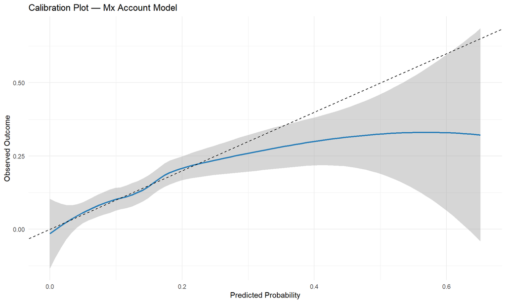

```
##
## ========================================
## Mx Account Model
## ========================================
##
## Training rows used: 2195
## Testing rows used: 942
##
## AIC:
## [1] 1669.154
##
## Likelihood Ratio Test:
## Analysis of Deviance Table
##
## Model 1: progressed ~ 1
## Model 2: progressed ~ acct_target_industry + acct_manufacturing_model +
##     acct_primary_site_function + acct_tier_rollup + acct_territory_rollup
##   Resid. Df Resid. Dev Df Deviance  Pr(>Chi)
## 1      2194     1736.3
## 2      2165     1609.2 29   127.12 2.998e-14 ***
## ---
## Signif. codes:  0 '***' 0.001 '**' 0.01 '*' 0.05 '.' 0.1 ' ' 1
##
## Pseudo R-squared:
##           llh       llhNull            G2      McFadden          r2ML
## -804.57695902 -868.13796318  127.12200833    0.07321533    0.05626923
##          r2CU
##    0.10294121
## <div id="osncjrvket" style="padding-left:0px;padding-right:0px;padding-top:10px;padding-bottom:10px;overflow-x:auto;overflow-y:auto;width:auto;height:auto;">
##   <style>#osncjrvket table {
##   font-family: system-ui, 'Segoe UI', Roboto, Helvetica, Arial, sans-serif, 'Apple Color Emoji', 'Segoe UI Emoji', 'Segoe UI Symbol', 'Noto Color Emoji';
##   -webkit-font-smoothing: antialiased;
##   -moz-osx-font-smoothing: grayscale;
## }
##
## #osncjrvket thead, #osncjrvket tbody, #osncjrvket tfoot, #osncjrvket tr, #osncjrvket td, #osncjrvket th {
##   border-style: none;
## }
##
## #osncjrvket p {
```

[output cut: 646 more lines]

[output not shown]

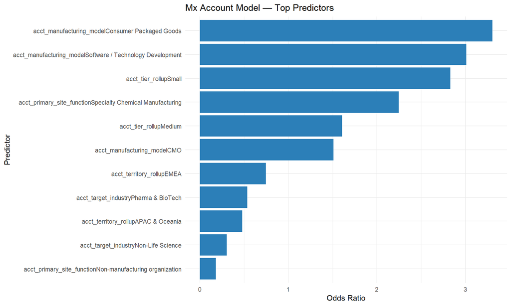

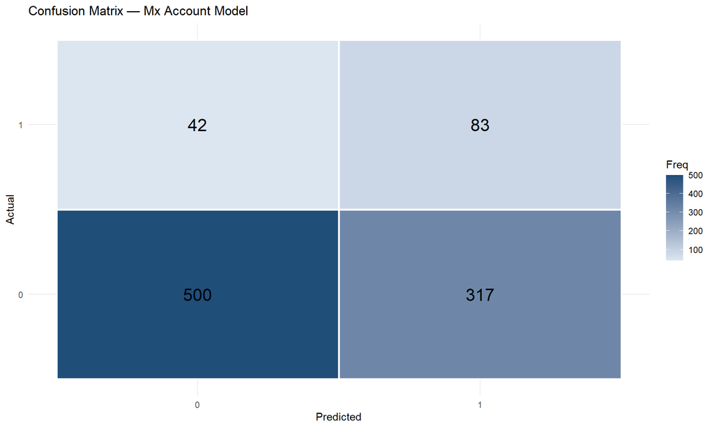

[output not shown]

[output cut: 422 more lines]

[output not shown]

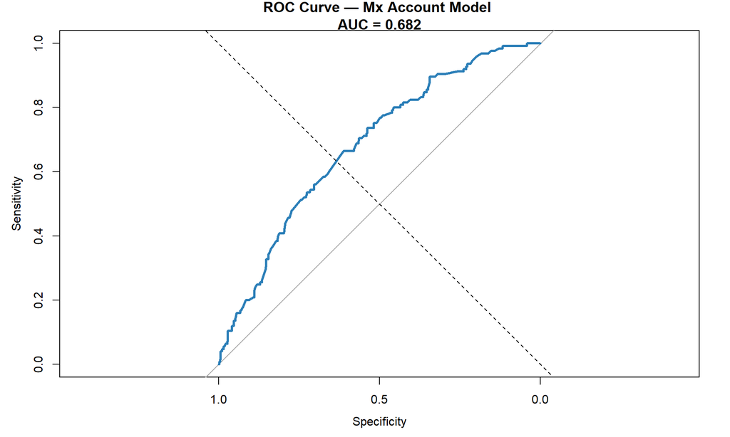

```r
# ==================================================
# Logistic Modeling Function
# ==================================================

library(broom)
library(caret)
library(yardstick)
library(pROC)
library(pscl)
library(ggplot2)

run_logistic_model <- function(train_df, test_df, formula_obj, model_title) {

  target_var <- all.vars(formula_obj)[1]
  vars_needed <- all.vars(formula_obj)

  # Keep only rows complete for variables in the formula
  train_model_data <- train_df %>%
    select(all_of(vars_needed)) %>%
    drop_na()

  test_model_data <- test_df %>%
    select(all_of(vars_needed)) %>%
    drop_na()

  # Fit full and null models
  full_model <- glm(
    formula_obj,
    data = train_model_data,
    family = binomial
  )

  null_model <- glm(
    as.formula(paste(target_var, "~ 1")),
    data = train_model_data,
    family = binomial
  )

  # Likelihood ratio test
  lr_test <- anova(null_model, full_model, test = "Chisq")

  # Pseudo R2
  pseudo_r2 <- pscl::pR2(full_model)

  # Coefficients
  coef_tbl <- broom::tidy(full_model, conf.int = TRUE) %>%
    mutate(
      odds_ratio = exp(estimate),
      or_conf_low = exp(conf.low),
      or_conf_high = exp(conf.high),
      significance = case_when(
        p.value < 0.001 ~ "*** Highly Significant",
        p.value < 0.01  ~ "** Very Significant",
        p.value < 0.05  ~ "* Significant",
        TRUE ~ "Not Significant"
      )
    ) %>%
    filter(term != "(Intercept)") %>%
    arrange(p.value)

  # --------------------------------------------------
  # Align factor levels with model training levels
  # --------------------------------------------------

  for (v in names(full_model$xlevels)) {
    test_model_data[[v]] <- factor(
      test_model_data[[v]],
      levels = full_model$xlevels[[v]]
    )
  }

  # Remove rows with unseen levels
  test_model_data <- test_model_data %>%
    drop_na()

  cat("Rows remaining in test dataset after alignment:",
      nrow(test_model_data), "\n")

  # --------------------------------------------------
  # Predictions on test data
  # --------------------------------------------------

  test_model_data$pred_prob <- predict(
    full_model,
    newdata = test_model_data,
    type = "response"
  )

  # --------------------------------------------------
  # Calibration Plot
  # --------------------------------------------------

  calibration_df <- data.frame(
    prob = test_model_data$pred_prob,
    actual = as.numeric(as.character(test_model_data[[target_var]]))
  )

  print(
    ggplot(calibration_df, aes(x = prob, y = actual)) +
      geom_smooth(method = "loess", color = "#2C7FB8") +
      geom_abline(slope = 1, intercept = 0, linetype = "dashed") +
      labs(
        title = paste("Calibration Plot —", model_title),
        x = "Predicted Probability",
        y = "Observed Outcome"
      ) +
      theme_minimal()
  )

  # --------------------------------------------------
  # Determine threshold using TRAIN data (avoid leakage)
  # --------------------------------------------------

  train_model_data$train_prob <- predict(
    full_model,
    newdata = train_model_data,
    type = "response"
  )

  roc_train <- roc(
    train_model_data[[target_var]],
    train_model_data$train_prob
  )

  optimal_threshold <- as.numeric(
    coords(roc_train, x = "best", ret = "threshold")
  )

  test_model_data$pred_class <- ifelse(
    test_model_data$pred_prob >= optimal_threshold,
    1,
    0
  )

  test_model_data$pred_class <- factor(test_model_data$pred_class, levels = c(0, 1))

  conf_matrix <- confusionMatrix(
    test_model_data$pred_class,
    test_model_data[[target_var]],
    positive = "1"
  )

  roc_obj <- roc(
    test_model_data[[target_var]],
    test_model_data$pred_prob
  )

  metrics_tbl <- tibble(
    Metric = c("Accuracy", "Precision", "Recall", "F1 Score", "AUC", "Threshold"),
    Value = c(
      accuracy_vec(test_model_data[[target_var]], test_model_data$pred_class),
      precision_vec(test_model_data[[target_var]], test_model_data$pred_class, event_level = "second"),
      recall_vec(test_model_data[[target_var]], test_model_data$pred_class, event_level = "second"),
      f_meas_vec(test_model_data[[target_var]], test_model_data$pred_class, event_level = "second"),
      as.numeric(auc(roc_obj)),
      optimal_threshold
    )
  )

  # Output
  cat("\n========================================\n")
  cat(model_title, "\n")
  cat("========================================\n\n")

  cat("Training rows used:", nrow(train_model_data), "\n")
  cat("Testing rows used:", nrow(test_model_data), "\n\n")

  cat("AIC:\n")
  print(AIC(full_model))

  cat("\nLikelihood Ratio Test:\n")
  print(lr_test)

  cat("\nPseudo R-squared:\n")
  print(pseudo_r2)

  print(
    coef_tbl %>%
      select(
        Predictor = term,
        Estimate = estimate,
        `Odds Ratio` = odds_ratio,
        `CI Lower` = or_conf_low,
        `CI Upper` = or_conf_high,
        `p-value` = p.value,
        Significance = significance
      ) %>%
      gt() %>%
      tab_header(title = paste(model_title, "— Significant Predictors")) %>%
      fmt_number(
        columns = c(Estimate, `Odds Ratio`, `CI Lower`, `CI Upper`, `p-value`),
        decimals = 4
      )
  )

  top_coef <- coef_tbl %>%
    filter(p.value < 0.10) %>%
    slice_head(n = 15)

  print(
    ggplot(top_coef, aes(x = reorder(term, odds_ratio), y = odds_ratio)) +
      geom_col(fill = "#2C7FB8") +
      coord_flip() +
      labs(
        title = paste(model_title, "— Top Predictors"),
        x = "Predictor",
        y = "Odds Ratio"
      ) +
      theme_minimal()
  )

  conf_df <- as.data.frame(conf_matrix$table)

  print(
    ggplot(conf_df, aes(x = Prediction, y = Reference, fill = Freq)) +
      geom_tile(color = "white", linewidth = 1) +
      geom_text(aes(label = Freq), size = 6) +
      scale_fill_gradient(low = "#DCE6F1", high = "#1F4E79") +
      labs(
        title = paste("Confusion Matrix —", model_title),
        x = "Predicted",
        y = "Actual"
      ) +
      theme_minimal()
  )

  print(
    metrics_tbl %>%
      gt() %>%
      tab_header(title = paste(model_title, "— Performance Metrics")) %>%
      fmt_number(columns = Value, decimals = 4)
  )

  plot(
    roc_obj,
    col = "#2C7FB8",
    lwd = 3,
    main = paste("ROC Curve —", model_title, "\nAUC =", round(as.numeric(auc(roc_obj)), 3))
  )
  abline(a = 0, b = 1, lty = 2)

  invisible(
    list(
      model = full_model,
      coefficients = coef_tbl,
      lr_test = lr_test,
      pseudo_r2 = pseudo_r2,
      confusion_matrix = conf_matrix,
      metrics = metrics_tbl,
      roc = roc_obj,
      threshold = optimal_threshold
    )
  )
}


# ==================================================
# Step 5 — Run Logistic Models for Deliverables
# ==================================================

set.seed(123)

# 5A. Account model for Mx
mx_account_train <- analysis_train %>%
  filter(solution_rollup == "Mx") %>%
  select(
    progressed,
    acct_target_industry,
    acct_manufacturing_model,
    acct_primary_site_function,
    acct_tier_rollup,
    acct_territory_rollup
  )

mx_account_test <- analysis_test %>%
  filter(solution_rollup == "Mx") %>%
  select(
    progressed,
    acct_target_industry,
    acct_manufacturing_model,
    acct_primary_site_function,
    acct_tier_rollup,
    acct_territory_rollup
  )

mx_account_results <- run_logistic_model(
  train_df = mx_account_train,
  test_df = mx_account_test,
  formula_obj = progressed ~ acct_target_industry +
    acct_manufacturing_model +
    acct_primary_site_function +
    acct_tier_rollup +
    acct_territory_rollup,
  model_title = "Mx Account Model"
)
```

```r
# 5B. Title model for Mx
mx_title_train <- analysis_train %>%
  filter(solution_rollup == "Mx") %>%
  select(progressed, title_seniority, title_function)

mx_title_test <- analysis_test %>%
  filter(solution_rollup == "Mx") %>%
  select(progressed, title_seniority, title_function)

mx_title_results <- run_logistic_model(
  train_df = mx_title_train,
  test_df = mx_title_test,
  formula_obj = progressed ~ title_seniority + title_function,
  model_title = "Mx Title Model"
)
```

```
## fitting null model for pseudo-r2
## Rows remaining in test dataset after alignment: 1222
```

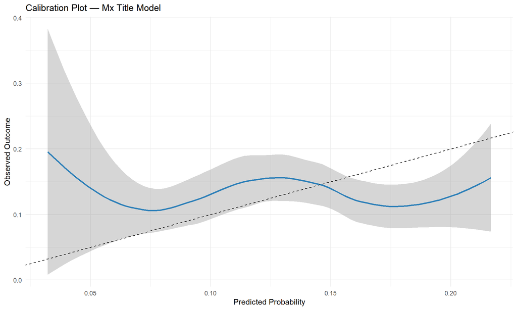

```
##
## ========================================
## Mx Title Model
## ========================================
##
## Training rows used: 2859
## Testing rows used: 1222
##
## AIC:
## [1] 2201.185
##
## Likelihood Ratio Test:
## Analysis of Deviance Table
##
## Model 1: progressed ~ 1
## Model 2: progressed ~ title_seniority + title_function
##   Resid. Df Resid. Dev Df Deviance  Pr(>Chi)
## 1      2858     2222.0
## 2      2843     2169.2 15   52.801 4.162e-06 ***
## ---
## Signif. codes:  0 '***' 0.001 '**' 0.01 '*' 0.05 '.' 0.1 ' ' 1
##
## Pseudo R-squared:
##           llh       llhNull            G2      McFadden          r2ML
## -1.084592e+03 -1.110993e+03  5.280066e+01  2.376283e-02  1.829873e-02
##          r2CU
##  3.386748e-02
## <div id="hzgjisdnqk" style="padding-left:0px;padding-right:0px;padding-top:10px;padding-bottom:10px;overflow-x:auto;overflow-y:auto;width:auto;height:auto;">
##   <style>#hzgjisdnqk table {
##   font-family: system-ui, 'Segoe UI', Roboto, Helvetica, Arial, sans-serif, 'Apple Color Emoji', 'Segoe UI Emoji', 'Segoe UI Symbol', 'Noto Color Emoji';
##   -webkit-font-smoothing: antialiased;
##   -moz-osx-font-smoothing: grayscale;
## }
##
## #hzgjisdnqk thead, #hzgjisdnqk tbody, #hzgjisdnqk tfoot, #hzgjisdnqk tr, #hzgjisdnqk td, #hzgjisdnqk th {
##   border-style: none;
## }
##
## #hzgjisdnqk p {
##   margin: 0;
```

[output cut: 554 more lines]

[output not shown]

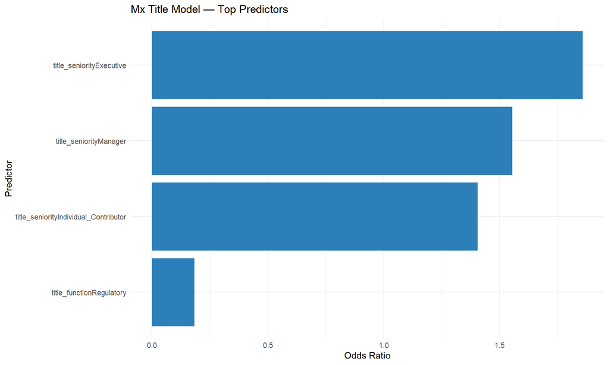

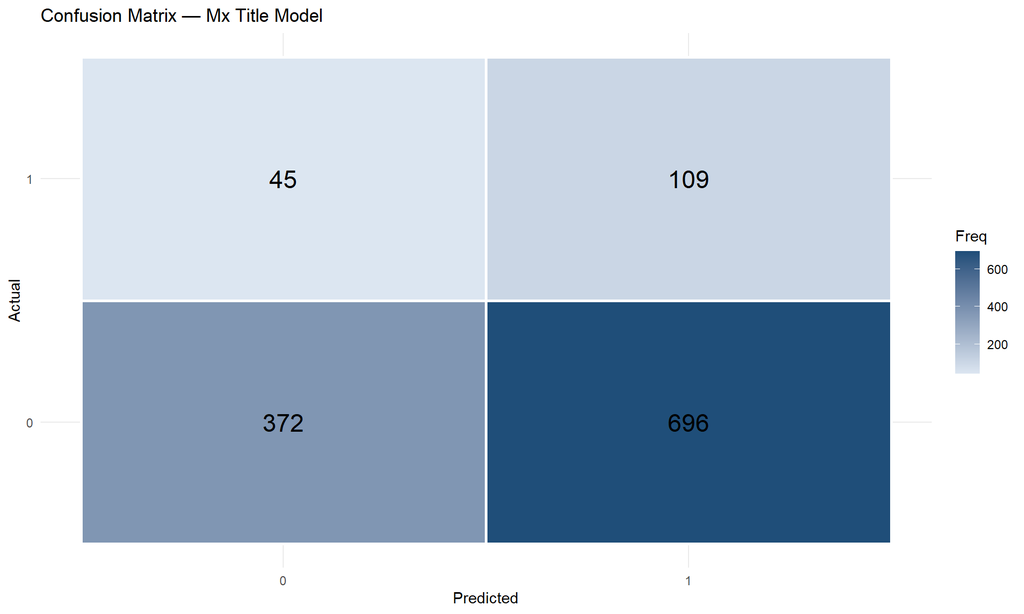

[output not shown]

[output cut: 422 more lines]

[output not shown]

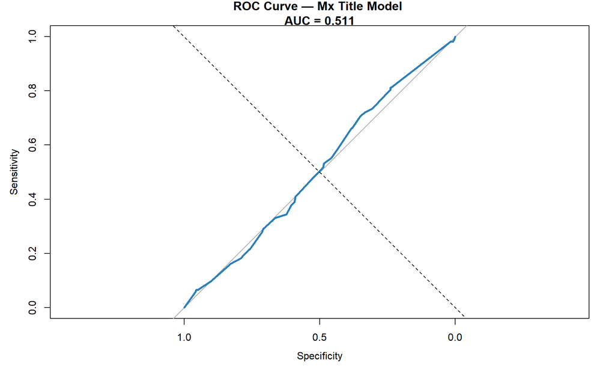

```r
# 5C. Combined model for Mx
mx_combined_train <- analysis_train %>%
  filter(solution_rollup == "Mx") %>%
  select(
    progressed,
    acct_target_industry,
    acct_manufacturing_model,
    acct_primary_site_function,
    acct_tier_rollup,
    title_seniority,
    title_function
  )

mx_combined_test <- analysis_test %>%
  filter(solution_rollup == "Mx") %>%
  select(
    progressed,
    acct_target_industry,
    acct_manufacturing_model,
    acct_primary_site_function,
    acct_tier_rollup,
    title_seniority,
    title_function
  )

mx_combined_results <- run_logistic_model(
  train_df = mx_combined_train,
  test_df = mx_combined_test,
  formula_obj = progressed ~ acct_target_industry +
    acct_manufacturing_model +
    acct_primary_site_function +
    acct_tier_rollup +
    title_seniority +
    title_function,
  model_title = "Mx Combined Account + Title Model"
)
```

```
## fitting null model for pseudo-r2
```

```
## Rows remaining in test dataset after alignment: 950
```

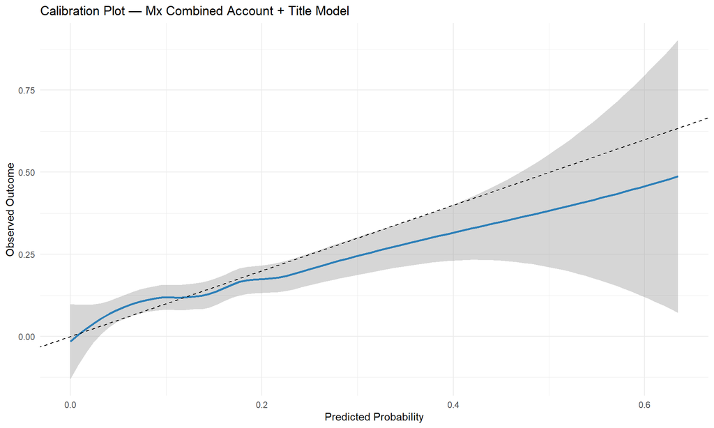

```
##
## ========================================
## Mx Combined Account + Title Model
## ========================================
##
## Training rows used: 2199
## Testing rows used: 950
##
## AIC:
## [1] 1684.03
##
## Likelihood Ratio Test:
## Analysis of Deviance Table
##
## Model 1: progressed ~ 1
## Model 2: progressed ~ acct_target_industry + acct_manufacturing_model +
##     acct_primary_site_function + acct_tier_rollup + title_seniority +
##     title_function
##   Resid. Df Resid. Dev Df Deviance Pr(>Chi)
## 1      2198     1737.4
## 2      2157     1600.0 41    137.4 2.47e-12 ***
## ---
## Signif. codes:  0 '***' 0.001 '**' 0.01 '*' 0.05 '.' 0.1 ' ' 1
##
## Pseudo R-squared:
##           llh       llhNull            G2      McFadden          r2ML
## -800.01475073 -868.71681429  137.40412711    0.07908453    0.06057268
##          r2CU
##    0.11089808
## <div id="wugufybehl" style="padding-left:0px;padding-right:0px;padding-top:10px;padding-bottom:10px;overflow-x:auto;overflow-y:auto;width:auto;height:auto;">
##   <style>#wugufybehl table {
##   font-family: system-ui, 'Segoe UI', Roboto, Helvetica, Arial, sans-serif, 'Apple Color Emoji', 'Segoe UI Emoji', 'Segoe UI Symbol', 'Noto Color Emoji';
##   -webkit-font-smoothing: antialiased;
##   -moz-osx-font-smoothing: grayscale;
## }
##
## #wugufybehl thead, #wugufybehl tbody, #wugufybehl tfoot, #wugufybehl tr, #wugufybehl td, #wugufybehl th {
##   border-style: none;
## }
##
```

[output cut: 738 more lines]

[output not shown]

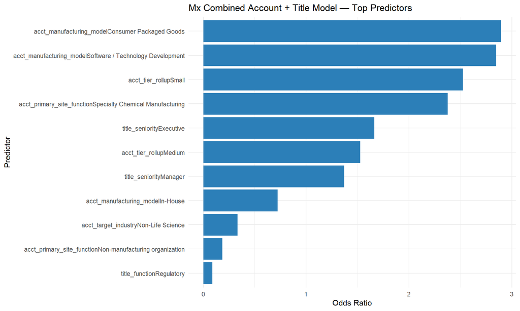

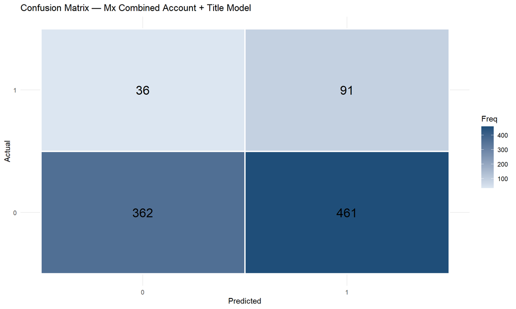

[output not shown]

[output cut: 422 more lines]

[output not shown]

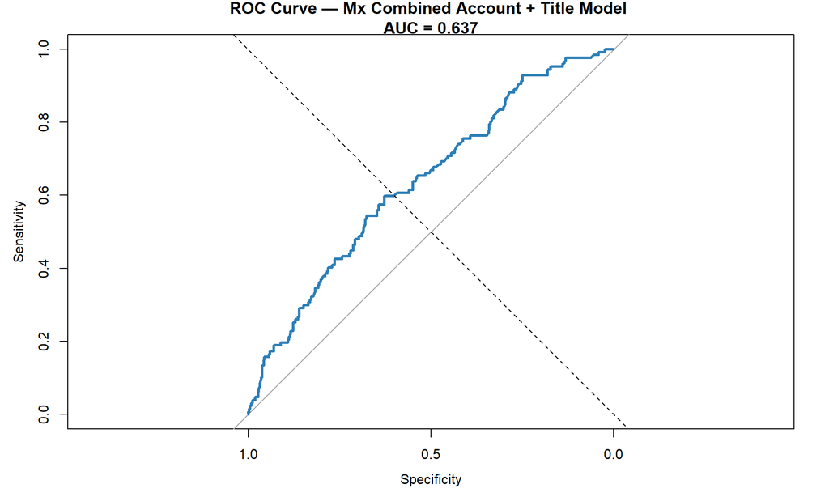

```r
# 5D. Cross-product model: Mx vs Qx
cross_train <- analysis_train %>%
  filter(solution_rollup %in% c("Mx", "Qx")) %>%
  mutate(mx_product = factor(ifelse(solution_rollup == "Mx", 1, 0), levels = c(0,1))) %>%
  select(
    mx_product,
    acct_target_industry,
    acct_manufacturing_model,
    acct_primary_site_function,
    acct_tier_rollup,
    acct_territory_rollup,
    title_seniority,
    title_function
  )

cross_test <- analysis_test %>%
  filter(solution_rollup %in% c("Mx", "Qx")) %>%
  mutate(mx_product = factor(ifelse(solution_rollup == "Mx", 1, 0), levels = c(0,1))) %>%
  select(
    mx_product,
    acct_target_industry,
    acct_manufacturing_model,
    acct_primary_site_function,
    acct_tier_rollup,
    acct_territory_rollup,
    title_seniority,
    title_function
  )

cross_results <- run_logistic_model(
  train_df = cross_train,
  test_df = cross_test,
  formula_obj = mx_product ~ acct_target_industry +
    acct_manufacturing_model +
    acct_primary_site_function +
    acct_tier_rollup +
    acct_territory_rollup +
    title_seniority +
    title_function,
  model_title = "Mx vs Qx Cross-Sell Model"
)
```

```
## fitting null model for pseudo-r2
## Rows remaining in test dataset after alignment: 3412
```

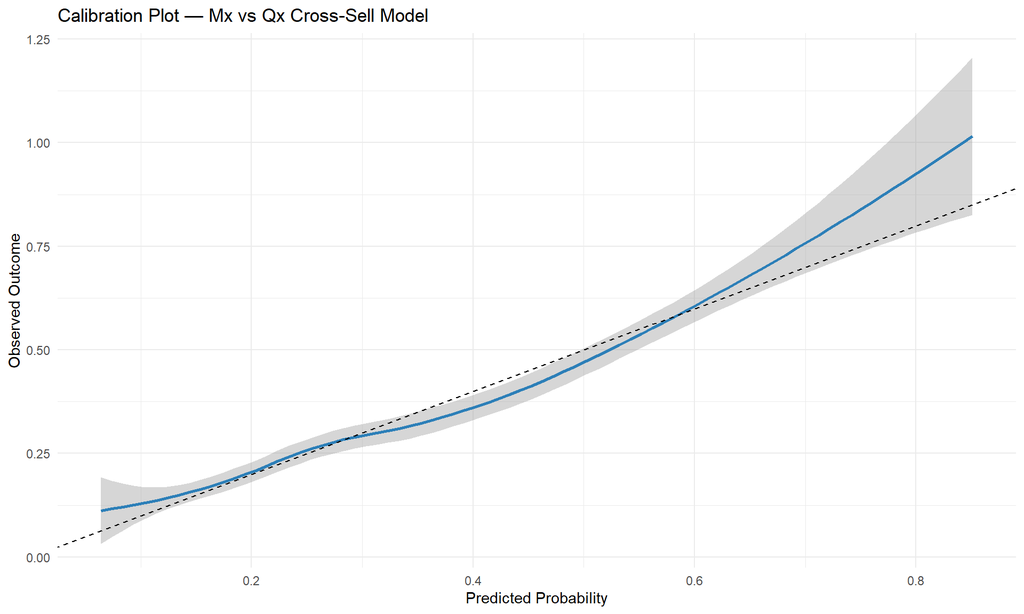

```
##
## ========================================
## Mx vs Qx Cross-Sell Model
## ========================================
##
## Training rows used: 7988
## Testing rows used: 3412
##
## AIC:
## [1] 8644.637
##
## Likelihood Ratio Test:
## Analysis of Deviance Table
##
## Model 1: mx_product ~ 1
## Model 2: mx_product ~ acct_target_industry + acct_manufacturing_model +
##     acct_primary_site_function + acct_tier_rollup + acct_territory_rollup +
##     title_seniority + title_function
##   Resid. Df Resid. Dev Df Deviance  Pr(>Chi)
## 1      7987     9393.3
## 2      7943     8554.6 44   838.65 < 2.2e-16 ***
## ---
## Signif. codes:  0 '***' 0.001 '**' 0.01 '*' 0.05 '.' 0.1 ' ' 1
##
## Pseudo R-squared:
##           llh       llhNull            G2      McFadden          r2ML
## -4.277318e+03 -4.696643e+03  8.386496e+02  8.928181e-02  9.966529e-02
##          r2CU
##  1.441361e-01
## <div id="zptfkhvvgp" style="padding-left:0px;padding-right:0px;padding-top:10px;padding-bottom:10px;overflow-x:auto;overflow-y:auto;width:auto;height:auto;">
##   <style>#zptfkhvvgp table {
##   font-family: system-ui, 'Segoe UI', Roboto, Helvetica, Arial, sans-serif, 'Apple Color Emoji', 'Segoe UI Emoji', 'Segoe UI Symbol', 'Noto Color Emoji';
##   -webkit-font-smoothing: antialiased;
##   -moz-osx-font-smoothing: grayscale;
## }
##
## #zptfkhvvgp thead, #zptfkhvvgp tbody, #zptfkhvvgp tfoot, #zptfkhvvgp tr, #zptfkhvvgp td, #zptfkhvvgp th {
##   border-style: none;
## }
##
```

[output cut: 759 more lines]

[output not shown]

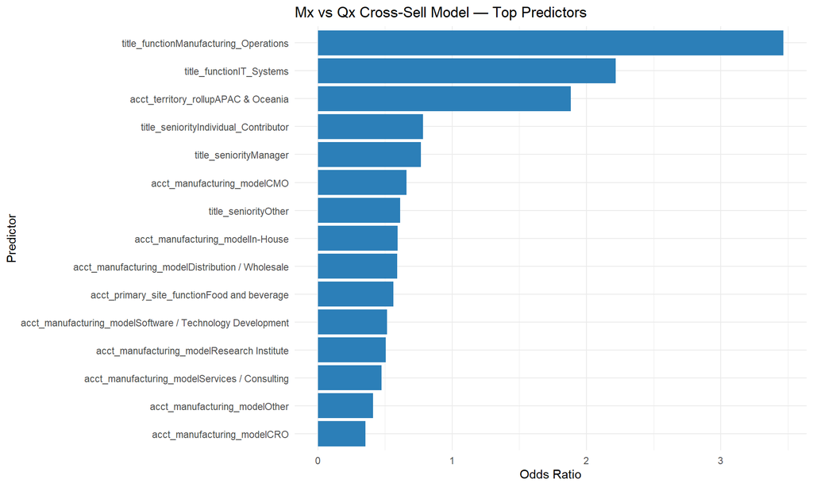

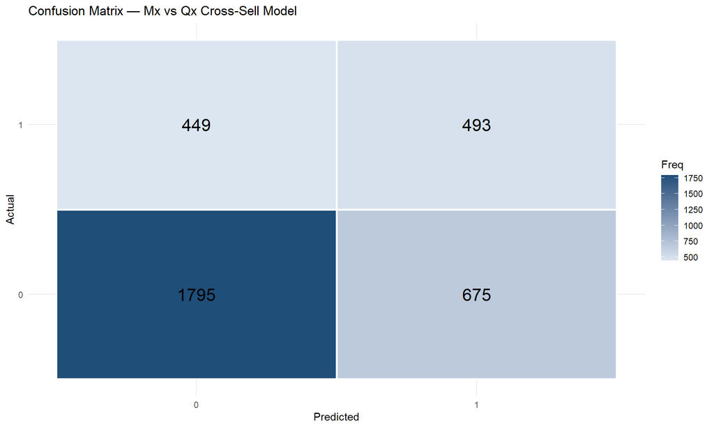

[output not shown]

[output cut: 422 more lines]

[output not shown]

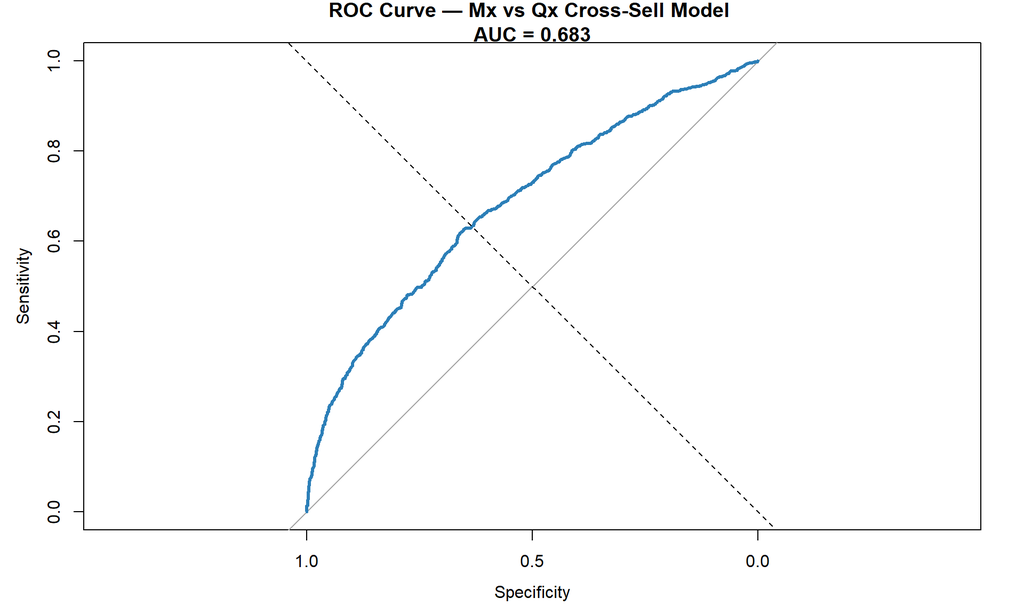

This chunk extends logistic regression by adding regularization, which helps stabilize estimates, handle correlated predictors, and automatically shrink less useful effects in a feature-rich setting.

[output not shown]

[output cut: 961 more lines]

[output not shown]

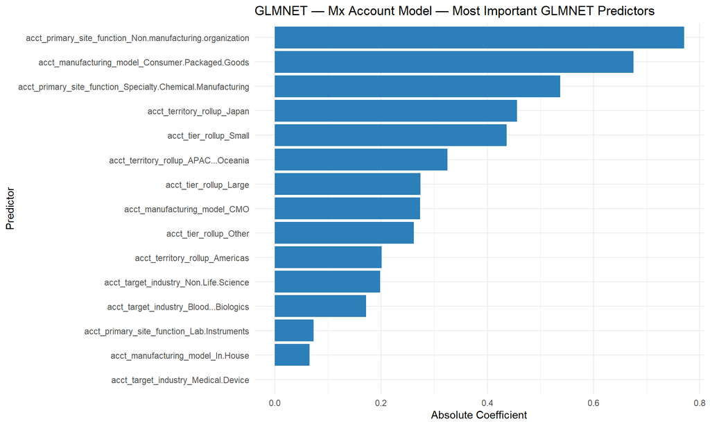

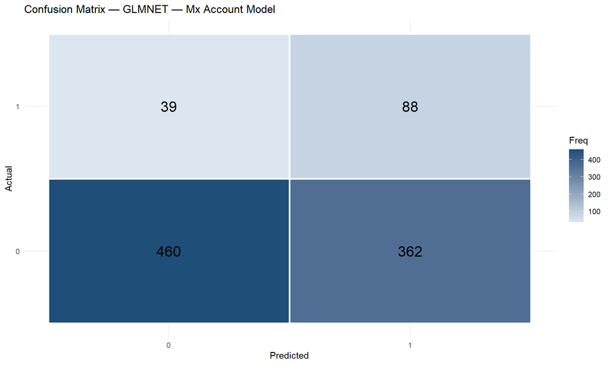

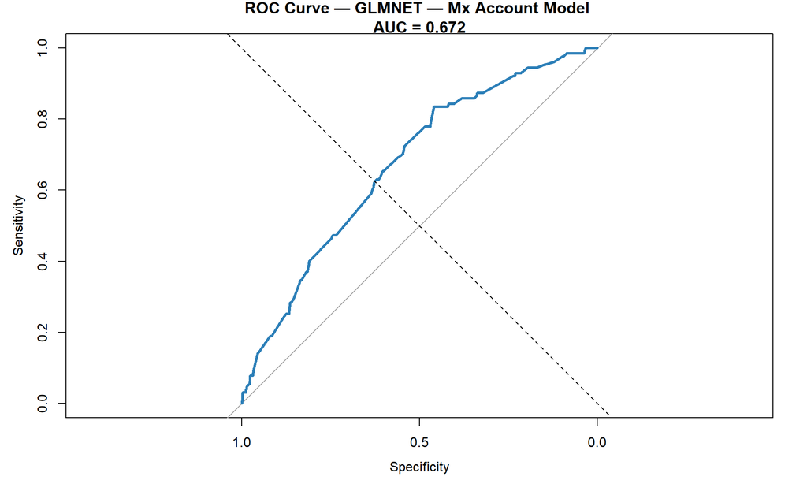

```r
# ==================================================
# GLMNET Logistic Regression Function
# ==================================================

library(glmnet)
library(recipes)
library(dplyr)
library(caret)
library(yardstick)
library(pROC)
library(tibble)
library(gt)
library(ggplot2)
library(broom)

run_glmnet_model <- function(train_df,
                             test_df,
                             formula_obj,
                             model_title,
                             alpha_value = 1) {

  target_var <- all.vars(formula_obj)[1]
  vars_needed <- all.vars(formula_obj)

  # --------------------------------------------------
  # Keep only required variables
  # --------------------------------------------------

  train_model_data <- train_df %>%
    select(all_of(vars_needed)) %>%
    drop_na()

  test_model_data <- test_df %>%
    select(all_of(vars_needed)) %>%
    drop_na()

  train_model_data[[target_var]] <- factor(train_model_data[[target_var]], levels = c(0, 1))
  test_model_data[[target_var]]  <- factor(test_model_data[[target_var]], levels = c(0, 1))

  # --------------------------------------------------
  # Recipe for dummy encoding
  # --------------------------------------------------

  glmnet_recipe <- recipe(formula_obj, data = train_model_data) %>%
    step_dummy(all_nominal_predictors(), one_hot = TRUE) %>%
    step_zv(all_predictors())

  glmnet_prep <- prep(glmnet_recipe, training = train_model_data)

  train_baked <- bake(glmnet_prep, new_data = train_model_data)
  test_baked  <- bake(glmnet_prep, new_data = test_model_data)

  # --------------------------------------------------
  # Prepare x and y
  # --------------------------------------------------

  train_x <- train_baked %>%
    select(-all_of(target_var)) %>%
    as.matrix()

  test_x <- test_baked %>%
    select(-all_of(target_var)) %>%
    as.matrix()

  train_y <- as.numeric(as.character(train_baked[[target_var]]))
  test_y  <- as.numeric(as.character(test_baked[[target_var]]))

  # --------------------------------------------------
  # Cross-validated GLMNET
  # alpha = 1  -> LASSO
  # alpha = 0  -> Ridge
  # alpha = 0.5 -> Elastic Net
  # --------------------------------------------------

  cv_glmnet <- cv.glmnet(
    x = train_x,
    y = train_y,
    family = "binomial",
    alpha = alpha_value,
    nfolds = 5,
    type.measure = "auc"
  )

  best_lambda <- cv_glmnet$lambda.min

  glmnet_model <- glmnet(
    x = train_x,
    y = train_y,
    family = "binomial",
    alpha = alpha_value,
    lambda = best_lambda
  )

  # --------------------------------------------------
  # Predictions
  # --------------------------------------------------

  train_prob <- as.numeric(
    predict(glmnet_model, newx = train_x, type = "response")
  )

  test_prob <- as.numeric(
    predict(glmnet_model, newx = test_x, type = "response")
  )

  # --------------------------------------------------
  # Threshold from TRAIN ROC
  # --------------------------------------------------

  roc_train <- roc(train_y, train_prob)

  optimal_threshold <- as.numeric(
    coords(roc_train, x = "best", ret = "threshold")
  )

  test_pred_class <- ifelse(test_prob >= optimal_threshold, 1, 0)

  test_pred_class_factor <- factor(test_pred_class, levels = c(0, 1))
  test_y_factor <- factor(test_y, levels = c(0, 1))

  # --------------------------------------------------
  # Confusion Matrix
  # --------------------------------------------------

  conf_matrix <- confusionMatrix(
    test_pred_class_factor,
    test_y_factor,
    positive = "1"
  )

  # --------------------------------------------------
  # ROC + Metrics
  # --------------------------------------------------

  roc_obj <- roc(test_y, test_prob)

  metrics_tbl <- tibble(
    Metric = c("Accuracy", "Precision", "Recall", "F1 Score", "AUC", "Threshold", "Best Lambda"),
    Value = c(
      accuracy_vec(test_y_factor, test_pred_class_factor),
      precision_vec(test_y_factor, test_pred_class_factor, event_level = "second"),
      recall_vec(test_y_factor, test_pred_class_factor, event_level = "second"),
      f_meas_vec(test_y_factor, test_pred_class_factor, event_level = "second"),
      as.numeric(auc(roc_obj)),
      optimal_threshold,
      best_lambda
    )
  )

  # --------------------------------------------------
  # Coefficients
  # --------------------------------------------------

  coef_mat <- as.matrix(coef(glmnet_model))
  coef_df <- tibble(
    term = rownames(coef_mat),
    estimate = as.numeric(coef_mat[,1])
  ) %>%
    filter(term != "(Intercept)") %>%
    mutate(
      odds_ratio = exp(estimate),
      abs_estimate = abs(estimate)
    ) %>%
    arrange(desc(abs_estimate))

  # --------------------------------------------------
  # Output
  # --------------------------------------------------

  cat("\n========================================\n")
  cat(model_title, "\n")
  cat("========================================\n\n")

  cat("Training rows used:", nrow(train_model_data), "\n")
  cat("Testing rows used:", nrow(test_model_data), "\n")
  cat("Alpha:", alpha_value, "\n")
  cat("Best Lambda:", best_lambda, "\n")
  cat("Threshold:", round(optimal_threshold, 4), "\n\n")

  print(
    metrics_tbl %>%
      gt() %>%
      tab_header(title = paste(model_title, "— Performance Metrics")) %>%
      fmt_number(columns = Value, decimals = 4)
  )

  print(
    coef_df %>%
      select(
        Predictor = term,
        Estimate = estimate,
        `Odds Ratio` = odds_ratio
      ) %>%
      slice_head(n = 20) %>%
      gt() %>%
      tab_header(title = paste(model_title, "— Top GLMNET Coefficients")) %>%
      fmt_number(columns = c(Estimate, `Odds Ratio`), decimals = 4)
  )

  top_coef <- coef_df %>%
    slice_head(n = 15)

  print(
    ggplot(top_coef, aes(x = reorder(term, abs_estimate), y = abs_estimate)) +
      geom_col(fill = "#2C7FB8") +
      coord_flip() +
      labs(
        title = paste(model_title, "— Most Important GLMNET Predictors"),
        x = "Predictor",
        y = "Absolute Coefficient"
      ) +
      theme_minimal()
  )

  conf_df <- as.data.frame(conf_matrix$table)

  print(
    ggplot(conf_df, aes(x = Prediction, y = Reference, fill = Freq)) +
      geom_tile(color = "white", linewidth = 1) +
      geom_text(aes(label = Freq), size = 6) +
      scale_fill_gradient(low = "#DCE6F1", high = "#1F4E79") +
      labs(
        title = paste("Confusion Matrix —", model_title),
        x = "Predicted",
        y = "Actual"
      ) +
      theme_minimal()
  )

  plot(
    roc_obj,
    col = "#2C7FB8",
    lwd = 3,
    main = paste("ROC Curve —", model_title, "\nAUC =", round(as.numeric(auc(roc_obj)), 3))
  )
  abline(a = 0, b = 1, lty = 2)

  invisible(
    list(
      model = glmnet_model,
      cv_model = cv_glmnet,
      coefficients = coef_df,
      confusion_matrix = conf_matrix,
      metrics = metrics_tbl,
      roc = roc_obj,
      threshold = optimal_threshold,
      lambda = best_lambda
    )
  )
}


# ==================================================
# Step 7 — Run GLMNET Models for Deliverables
# ==================================================

set.seed(123)

# 7A. GLMNET Account model for Mx
mx_account_glmnet <- run_glmnet_model(
  train_df = mx_account_train,
  test_df = mx_account_test,
  formula_obj = progressed ~ acct_target_industry +
    acct_manufacturing_model +
    acct_primary_site_function +
    acct_tier_rollup +
    acct_territory_rollup,
  model_title = "GLMNET — Mx Account Model",
  alpha_value = 1
)
```

```r
# 7B. GLMNET Title model for Mx
mx_title_glmnet <- run_glmnet_model(
  train_df = mx_title_train,
  test_df = mx_title_test,
  formula_obj = progressed ~ title_seniority + title_function,
  model_title = "GLMNET — Mx Title Model",
  alpha_value = 1
)
```

[output not shown]

[output cut: 955 more lines]

[output not shown]

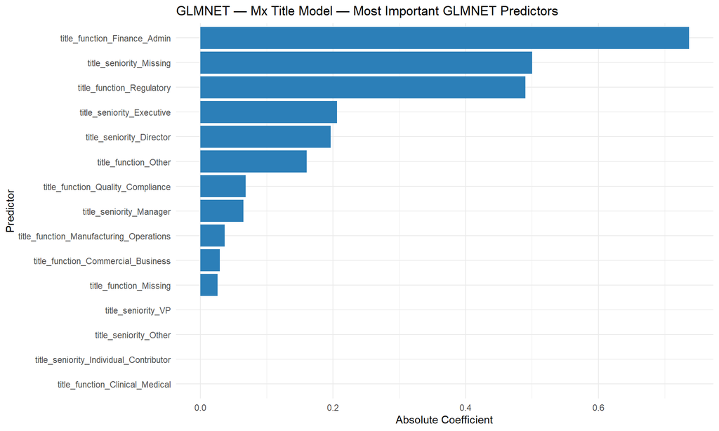

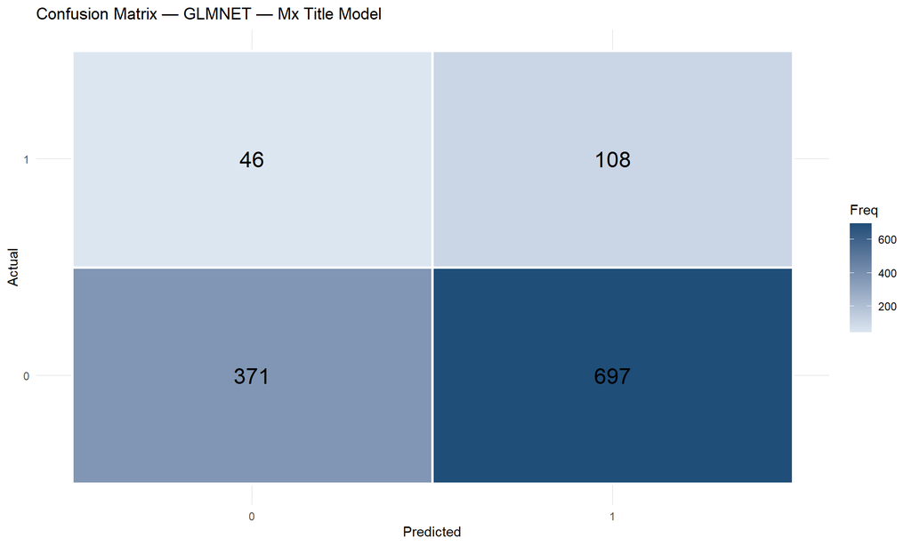

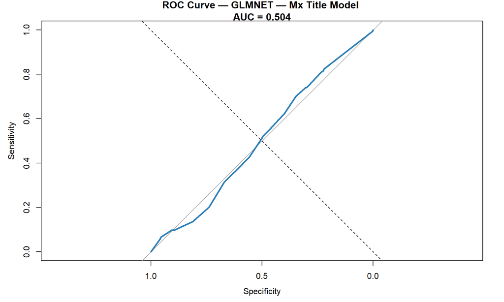

```r
# 7C. GLMNET Combined model for Mx
mx_combined_glmnet <- run_glmnet_model(
  train_df = mx_combined_train,
  test_df = mx_combined_test,
  formula_obj = progressed ~ acct_target_industry +
    acct_manufacturing_model +
    acct_primary_site_function +
    acct_tier_rollup +
    title_seniority +
    title_function,
  model_title = "GLMNET — Mx Combined Account + Title Model",
  alpha_value = 1
)
```

[output not shown]

[output cut: 961 more lines]

[output not shown]

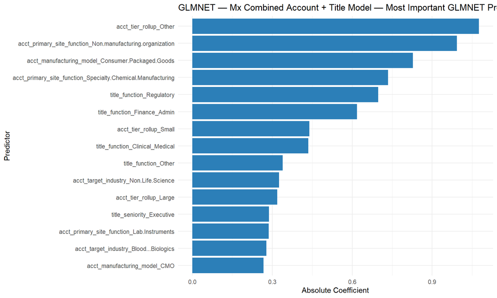

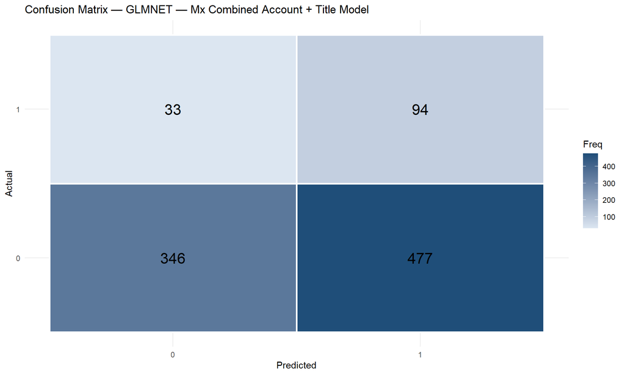

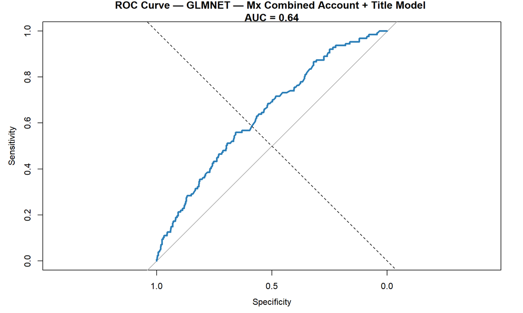

```r
# 7D. GLMNET Cross-product model: Mx vs Qx
cross_glmnet <- run_glmnet_model(
  train_df = cross_train,
  test_df = cross_test,
  formula_obj = mx_product ~ acct_target_industry +
    acct_manufacturing_model +
    acct_primary_site_function +
    acct_tier_rollup +
    acct_territory_rollup +
    title_seniority +
    title_function,
  model_title = "GLMNET — Mx vs Qx Cross-Sell Model",
  alpha_value = 1
)
```

[output not shown]

[output cut: 961 more lines]

[output not shown]

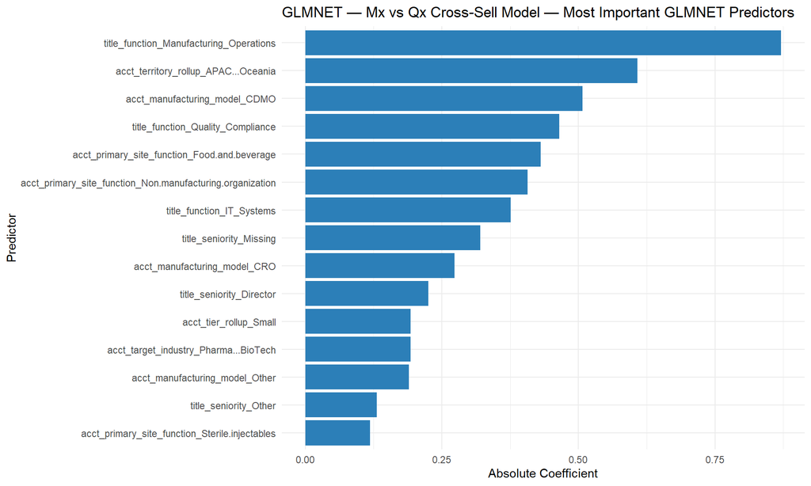

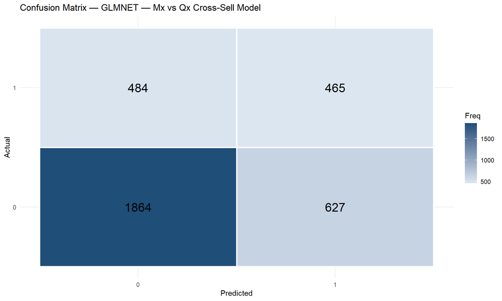

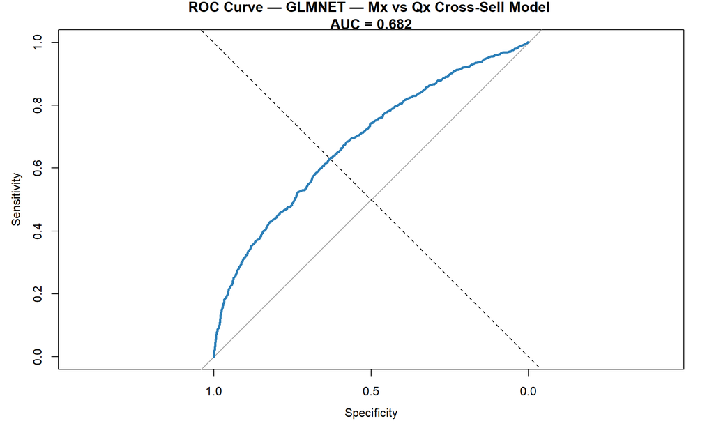

## 12.4 . Model 3: Decision Tree (CART)

This chunk fits a rule-based model that splits the data into practical segments, making it easier to visualize how combinations of account and title factors lead to stronger or weaker progression.

```r
# ==================================================
# Model 3 — Decision Tree (CART)
# Drivers of Mx Lead Progression
# ==================================================

library(rpart)
library(rpart.plot)
library(dplyr)
library(ggplot2)
library(caret)
library(yardstick)
library(pROC)
library(gt)
library(tibble)

set.seed(123)

# --------------------------------------------------
# Prepare Training and Testing Data
# --------------------------------------------------

mx_tree_train <- analysis_train %>%
  filter(solution_rollup == "Mx") %>%
  select(
    progressed,
    acct_target_industry,
    acct_manufacturing_model,
    acct_primary_site_function,
    acct_tier_rollup,
    acct_territory_rollup,
    title_seniority,
    title_function
  ) %>%
  drop_na()

mx_tree_test <- analysis_test %>%
  filter(solution_rollup == "Mx") %>%
  select(
    progressed,
    acct_target_industry,
    acct_manufacturing_model,
    acct_primary_site_function,
    acct_tier_rollup,
    acct_territory_rollup,
    title_seniority,
    title_function
  ) %>%
  drop_na()

# Ensure target is factor
mx_tree_train$progressed <- factor(mx_tree_train$progressed, levels = c(0,1))
mx_tree_test$progressed  <- factor(mx_tree_test$progressed, levels = c(0,1))

# --------------------------------------------------
# Align Factor Levels Between Train/Test
# --------------------------------------------------

for(v in names(mx_tree_train)){

  if(is.factor(mx_tree_train[[v]])){

    mx_tree_test[[v]] <- factor(
      mx_tree_test[[v]],
      levels = levels(mx_tree_train[[v]])
    )

  }
}

mx_tree_test <- mx_tree_test %>% drop_na()

cat("Training rows:", nrow(mx_tree_train), "\n")
```

```
## Training rows: 2195
```

```r
cat("Testing rows:", nrow(mx_tree_test), "\n")
```

```
## Testing rows: 949
```

```r
# --------------------------------------------------
# Handle Class Imbalance
# --------------------------------------------------

class_weights <- ifelse(mx_tree_train$progressed == "1", 5, 1)

# --------------------------------------------------
# Train Decision Tree
# --------------------------------------------------

mx_tree_model <- rpart(

  progressed ~

    acct_target_industry +
    acct_manufacturing_model +
    acct_primary_site_function +
    acct_tier_rollup +
    acct_territory_rollup +
    title_seniority +
    title_function,

  data = mx_tree_train,
  method = "class",
  weights = class_weights,

  control = rpart.control(
    cp = 0.001,
    minsplit = 20,
    maxdepth = 6
  )
)

print(mx_tree_model)
```

```
## n= 2195
##
## node), split, n, loss, yval, (yprob)
##       * denotes terminal node
##
##   1) root 2195 1480 0 (0.56200059 0.43799941)
##     2) acct_primary_site_function=Non-manufacturing organization 464  135 0 (0.76398601 0.23601399)
##       4) title_seniority=Director,Missing,VP 228   20 0 (0.91803279 0.08196721)
##         8) acct_target_industry=Non-Life Science,Pharma & BioTech 201    5 0 (0.97560976 0.02439024) *
##         9) acct_target_industry=Blood & Biologics,Medical Device 27   15 0 (0.61538462 0.38461538)
##          18) acct_manufacturing_model=In-House,Research Institute,Services / Consulting,Software / Technology Development 13    0 0 (1.00000000 0.00000000) *
##          19) acct_manufacturing_model=CRO,Distribution / Wholesale,Other 14   11 1 (0.42307692 0.57692308) *
##       5) title_seniority=Executive,Individual_Contributor,Manager,Other 236  115 0 (0.64939024 0.35060976)
##        10) acct_manufacturing_model=CMO,CRO,In-House,Research Institute 44    0 0 (1.00000000 0.00000000) *
##        11) acct_manufacturing_model=CDMO,Distribution / Wholesale,Other,Services / Consulting,Software / Technology Development 192  115 0 (0.59507042 0.40492958)
##          22) acct_target_industry=Medical Device,Non-Life Science 124   45 0 (0.71875000 0.28125000)
##            44) title_function=Clinical_Medical,Commercial_Business,Engineering_RD,Finance_Admin,IT_Systems,Other,Quality_Compliance,Supply_Chain 108   25 0 (0.80468750 0.19531250) *
##            45) title_function=Manufacturing_Operations,Regulatory 16   12 1 (0.37500000 0.62500000) *
##          23) acct_target_industry=Blood & Biologics,Pharma & BioTech 68   54 1 (0.43548387 0.56451613)
##            46) title_function=Engineering_RD,Manufacturing_Operations,Quality_Compliance,Regulatory,Supply_Chain 25   10 0 (0.69696970 0.30303030) *
##            47) title_function=Commercial_Business,IT_Systems,Other 43   31 1 (0.34065934 0.65934066)
##              94) acct_manufacturing_model=Distribution / Wholesale,Other 15   10 0 (0.56521739 0.43478261) *
##              95) acct_manufacturing_model=CDMO,Services / Consulting,Software / Technology Development 28   18 1 (0.26470588 0.73529412) *
##     3) acct_primary_site_function=Diagnostic Equipment,Food and beverage,Implantable devices,In-vitro diagnostic (IVD) kits,Lab Instruments,Oral solid dosage (OSD),Other,Small-molecule API,Specialty Chemical Manufacturing,Sterile injectables 1731 1345 0 (0.52084076 0.47915924)
##       6) acct_territory_rollup=APAC & Oceania 417  175 0 (0.68581688 0.31418312)
##        12) acct_primary_site_function=Diagnostic Equipment,Implantable devices,In-vitro diagnostic (IVD) kits,Lab Instruments,Oral solid dosage (OSD),Other,Small-molecule API,Sterile injectables 394  130 0 (0.73895582 0.26104418)
##          24) title_function=Clinical_Medical,Commercial_Business,Engineering_RD,Finance_Admin,IT_Systems,Manufacturing_Operations,Missing,Quality_Compliance,Regulatory,Supply_Chain 331   80 0 (0.79746835 0.20253165)
##            48) acct_manufacturing_model=CDMO,CMO,Distribution / Wholesale,In-House,Original Equipment Manufacturing,Research Institute 324   70 0 (0.81578947 0.18421053) *
##            49) acct_manufacturing_model=Other,Software / Technology Development 7    5 1 (0.33333333 0.66666667) *
##          25) title_function=Other 63   50 0 (0.51456311 0.48543689)
##            50) acct_primary_site_function=Implantable devices,In-vitro diagnostic (IVD) kits,Lab Instruments,Small-molecule API 13    0 0 (1.00000000 0.00000000) *
##            51) acct_primary_site_function=Oral solid dosage (OSD),Other,Sterile injectables 50   40 1 (0.44444444 0.55555556)
##             102) title_seniority=Other,VP 9    0 0 (1.00000000 0.00000000) *
##             103) title_seniority=Director,Executive,Individual_Contributor,Manager 41   31 1 (0.38271605 0.61728395) *
##        13) acct_primary_site_function=Food and beverage,Specialty Chemical Manufacturing 23   14 1 (0.23728814 0.76271186) *
##       7) acct_territory_rollup=Americas,EMEA,Japan 1314 1080 1 (0.48000000 0.52000000)
##        14) title_function=IT_Systems,Manufacturing_Operations,Regulatory 396  250 0 (0.58053691 0.41946309)
```

[output cut: 19 more lines]

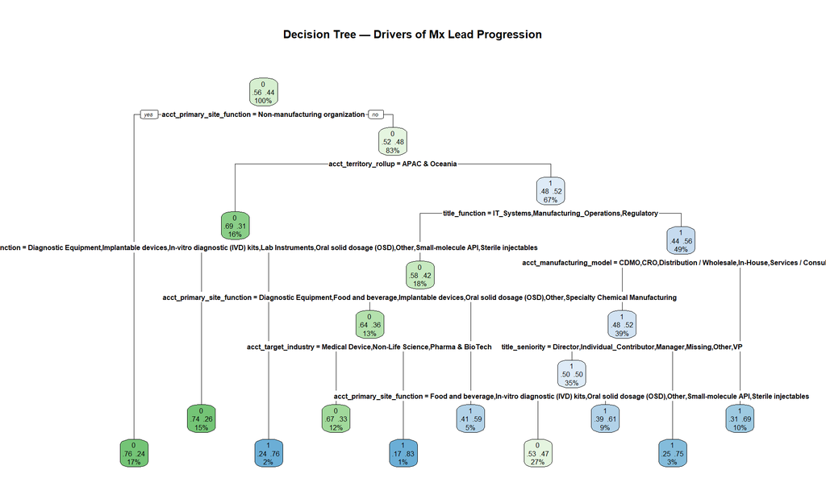

```r
# --------------------------------------------------
# Prune Tree using Cross-Validated Error
# --------------------------------------------------

best_cp <- mx_tree_model$cptable[
  which.min(mx_tree_model$cptable[,"xerror"]),
  "CP"
]

mx_tree_pruned <- rpart::prune(mx_tree_model, cp = best_cp)

# --------------------------------------------------
# Visualize Decision Tree
# --------------------------------------------------

rpart.plot(
  mx_tree_pruned,
  type = 2,
  extra = 104,
  fallen.leaves = TRUE,
  tweak = 1.3,
  box.palette = "GnBu",
  main = "Decision Tree — Drivers of Mx Lead Progression"
)
```

```r
# --------------------------------------------------
# Generate Predictions
# --------------------------------------------------

train_prob <- predict(
  mx_tree_pruned,
  newdata = mx_tree_train,
  type = "prob"
)[,2]

mx_tree_test$pred_prob <- predict(
  mx_tree_pruned,
  newdata = mx_tree_test,
  type = "prob"
)[,2]

# --------------------------------------------------
# Determine Optimal Threshold (TRAIN DATA)
# --------------------------------------------------

roc_train <- roc(mx_tree_train$progressed, train_prob)

optimal_threshold <- as.numeric(
  coords(roc_train, x = "best", ret = "threshold")
)

cat("Optimal Threshold:", optimal_threshold, "\n")
```

```
## Optimal Threshold: 0.4001388
```

```r
# --------------------------------------------------
# Apply Threshold to Test Predictions
# --------------------------------------------------

mx_tree_test$pred_class <- ifelse(
  mx_tree_test$pred_prob >= optimal_threshold,
  1,
  0
)

mx_tree_test$pred_class <- factor(mx_tree_test$pred_class, levels = c(0,1))

# --------------------------------------------------
# Confusion Matrix
# --------------------------------------------------

conf_matrix_tree <- confusionMatrix(
  mx_tree_test$pred_class,
  mx_tree_test$progressed,
  positive = "1"
)

conf_matrix_tree
```

```
## Confusion Matrix and Statistics
##
##           Reference
## Prediction   0   1
##          0 465  53
##          1 357  74
##
##                Accuracy : 0.568
##                  95% CI : (0.5358, 0.5998)
##     No Information Rate : 0.8662
##     P-Value [Acc > NIR] : 1
##
##                   Kappa : 0.0737
##
##  Mcnemar's Test P-Value : <2e-16
##
##             Sensitivity : 0.58268
##             Specificity : 0.56569
##          Pos Pred Value : 0.17169
##          Neg Pred Value : 0.89768
##              Prevalence : 0.13383
##          Detection Rate : 0.07798
##    Detection Prevalence : 0.45416
##       Balanced Accuracy : 0.57419
##
##        'Positive' Class : 1
##
```

```r
# --------------------------------------------------
# Model Performance Metrics
# --------------------------------------------------

metrics_tree <- tibble(
  Metric = c("Accuracy","Precision","Recall","F1 Score"),
  Value = c(
    accuracy_vec(mx_tree_test$progressed, mx_tree_test$pred_class),
    precision_vec(mx_tree_test$progressed, mx_tree_test$pred_class, event_level="second"),
    recall_vec(mx_tree_test$progressed, mx_tree_test$pred_class, event_level="second"),
    f_meas_vec(mx_tree_test$progressed, mx_tree_test$pred_class, event_level="second")
  )
)

metrics_tree %>%
  gt() %>%
  tab_header(title = "Decision Tree Model Performance Metrics") %>%
  fmt_number(columns = Value, decimals = 4)
```

Decision Tree Model Performance Metrics

| Metric | Value |
| --- | --- |
| Accuracy | 0.5680 |
| Precision | 0.1717 |
| Recall | 0.5827 |
| F1 Score | 0.2652 |

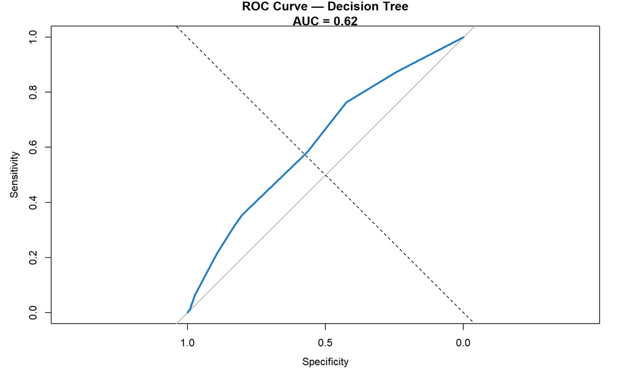

```r
# --------------------------------------------------
# ROC Curve
# --------------------------------------------------

roc_tree <- roc(mx_tree_test$progressed, mx_tree_test$pred_prob)
auc_tree <- auc(roc_tree)

plot(
  roc_tree,
  col = "#2C7FB8",
  lwd = 3,
  main = paste("ROC Curve — Decision Tree\nAUC =", round(auc_tree,3))
)

abline(a = 0, b = 1, lty = 2)
```

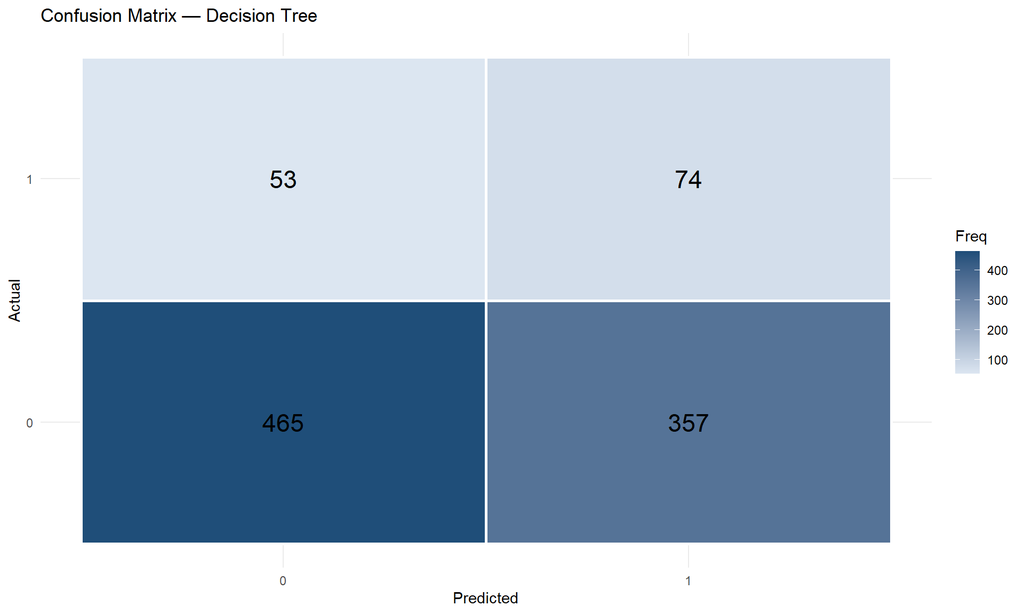

```r
# --------------------------------------------------
# Confusion Matrix Visualization
# --------------------------------------------------

conf_df <- as.data.frame(conf_matrix_tree$table)

ggplot(conf_df,
       aes(x = Prediction, y = Reference, fill = Freq)) +
  geom_tile(color = "white", linewidth = 1) +
  geom_text(aes(label = Freq), size = 6) +
  scale_fill_gradient(low = "#DCE6F1", high = "#1F4E79") +
  labs(
    title = "Confusion Matrix — Decision Tree",
    x = "Predicted",
    y = "Actual"
  ) +
  theme_minimal()
```

```r
# --------------------------------------------------
# Variable Importance
# --------------------------------------------------

var_imp <- tibble(
  Variable = names(mx_tree_pruned$variable.importance),
  Importance = as.numeric(mx_tree_pruned$variable.importance)
)

var_imp %>%
  arrange(desc(Importance)) %>%
  gt() %>%
  tab_header(title = "Decision Tree Variable Importance")
```

Decision Tree Variable Importance

| Variable | Importance |
| --- | --- |
| acct_primary_site_function | 103.4418744 |
| acct_manufacturing_model | 55.4592925 |
| acct_territory_rollup | 37.8257250 |
| title_function | 16.8145604 |
| acct_target_industry | 12.6638727 |
| title_seniority | 11.9274736 |
| acct_tier_rollup | 0.1276031 |

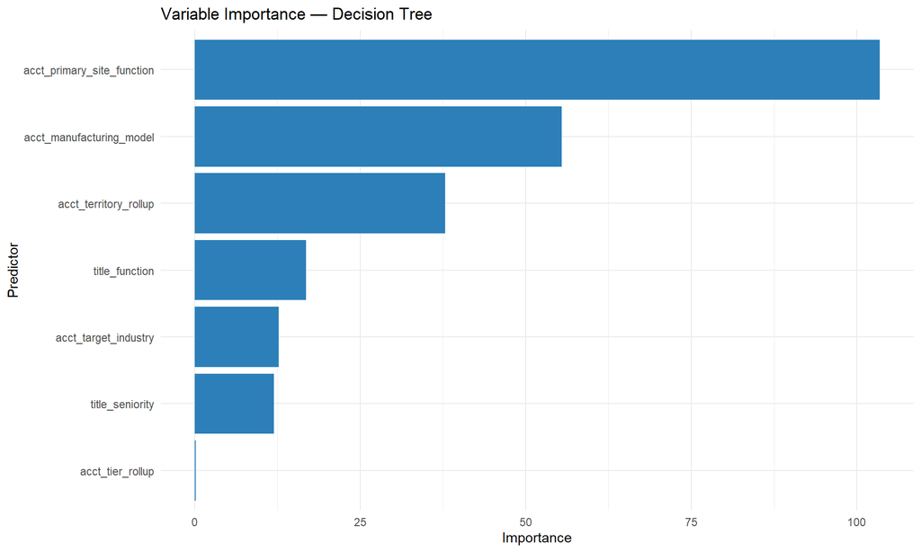

```r
ggplot(var_imp,
       aes(x = reorder(Variable, Importance), y = Importance)) +
  geom_col(fill = "#2C7FB8") +
  coord_flip() +
  labs(
    title = "Variable Importance — Decision Tree",
    x = "Predictor",
    y = "Importance"
  ) +
  theme_minimal()
```